# Engagement en IG de Tenistas ATP

#### followers

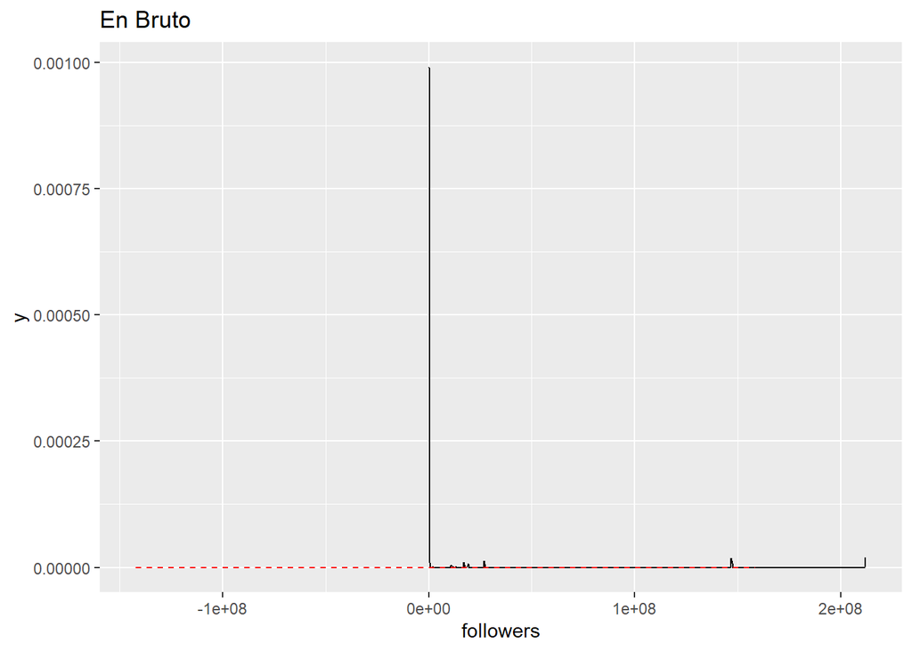

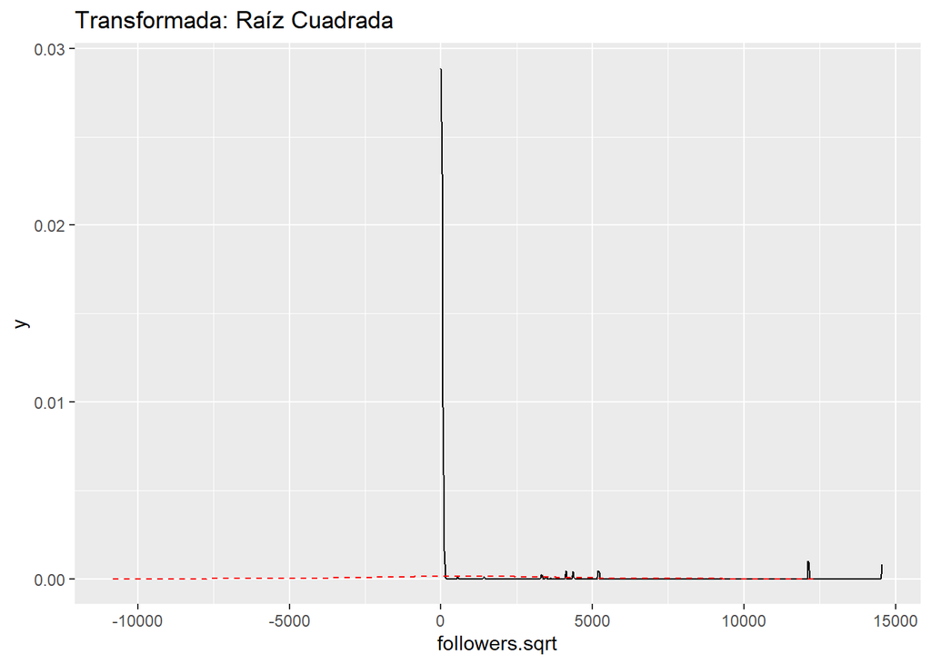

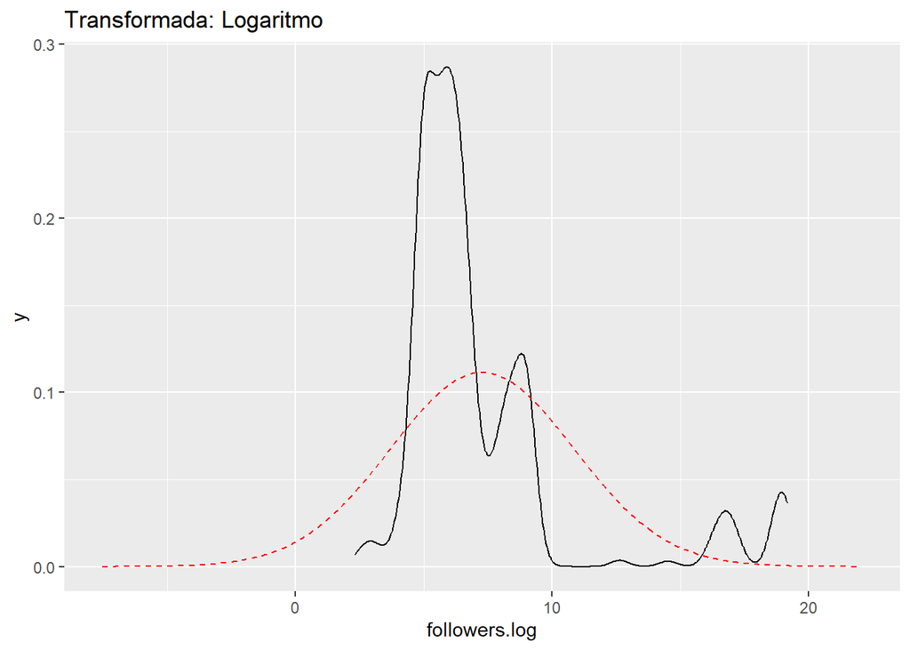

Resultados de los test de skewness para la variable followers.

| original.skewness | raiz.skewness | log.skewness |
| --- | --- | --- |
| 4.68263 | 4.020348 | 2.235001 |

#### following

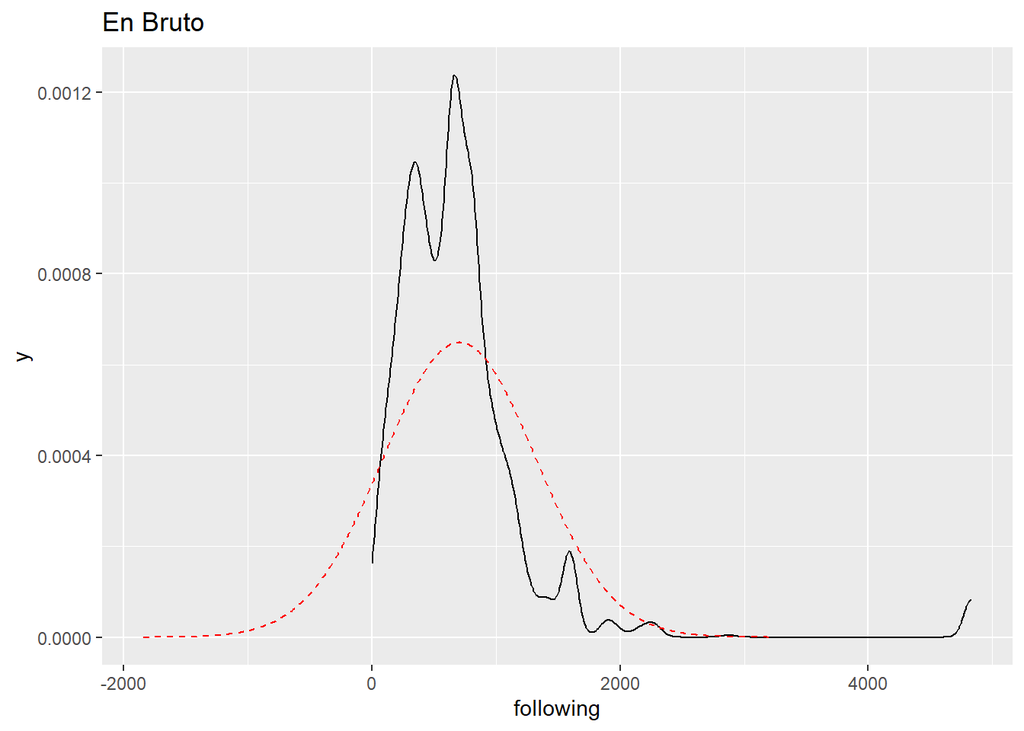

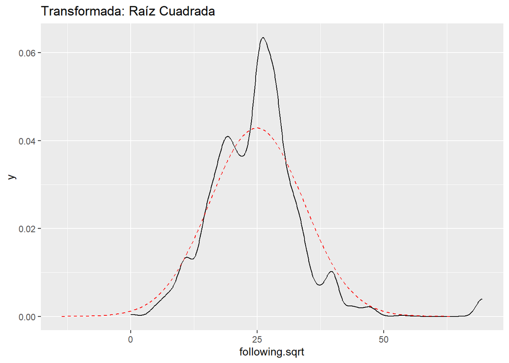

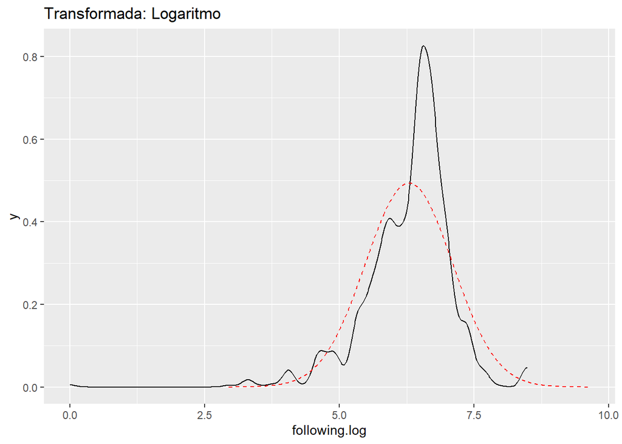

Resultados de los test de skewness para la variable following.

| original.skewness | raiz.skewness | log.skewness |
| --- | --- | --- |
| 4.144823 | 1.356793 | -1.299904 |

#### num_hashtags

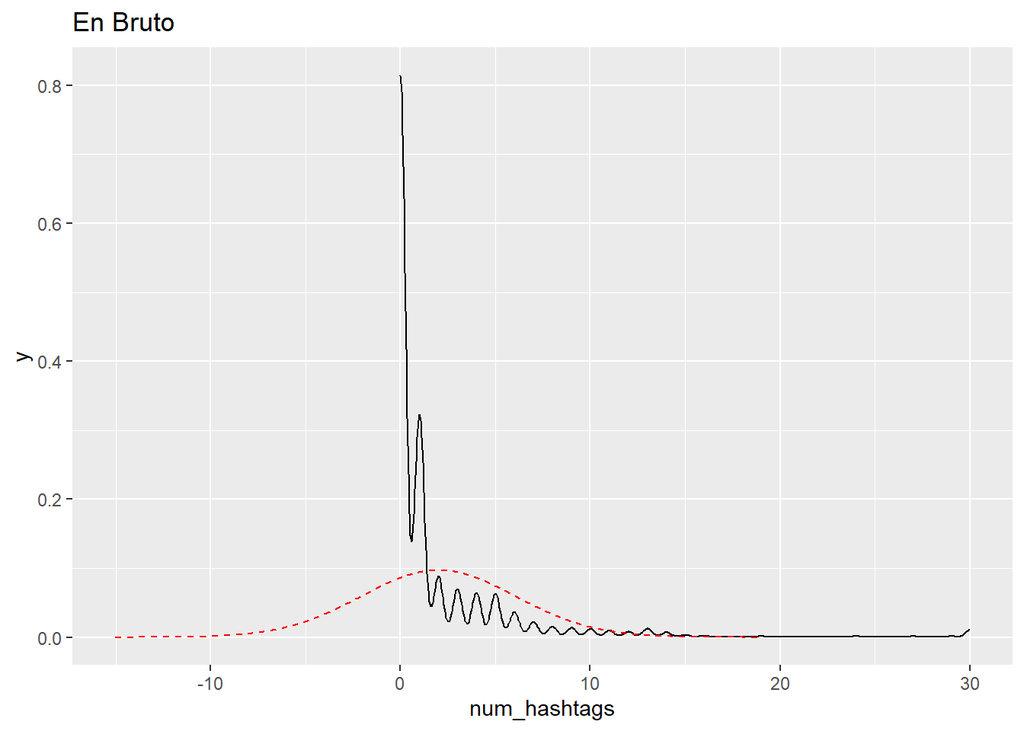

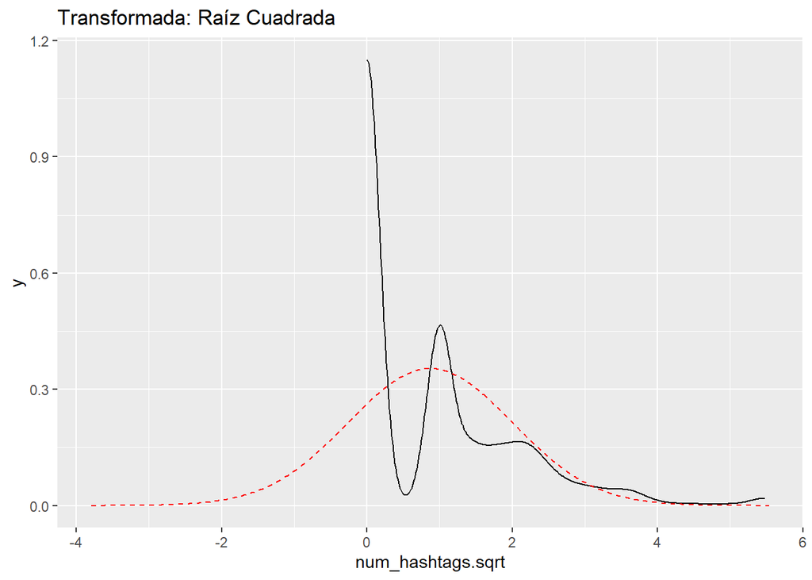

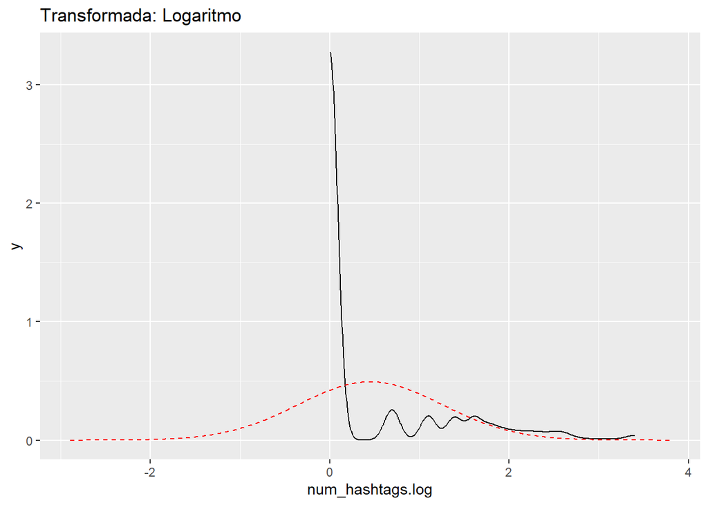

Resultados de los test de skewness para la variable num_hashtags.

| original.skewness | raiz.skewness | log.skewness |
| --- | --- | --- |
| 3.949552 | 1.391406 | 1.663476 |

#### num_mentions

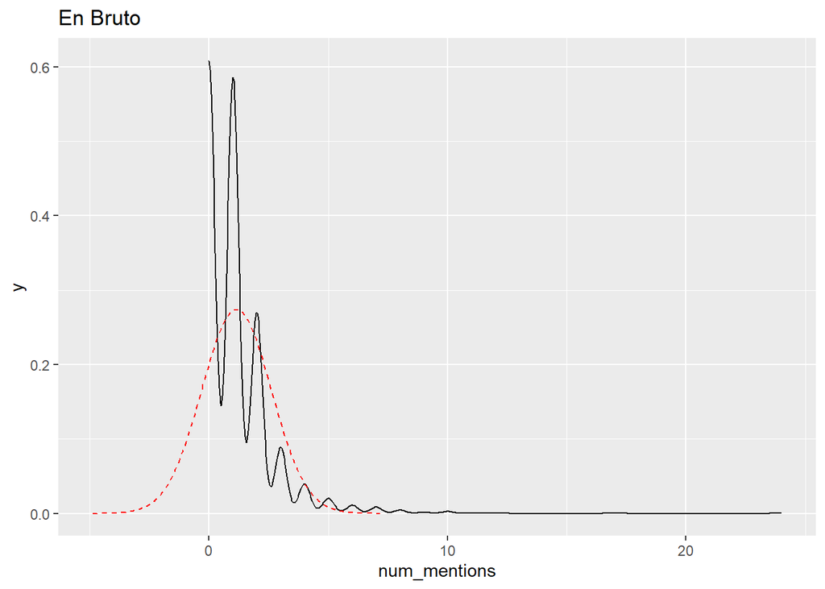

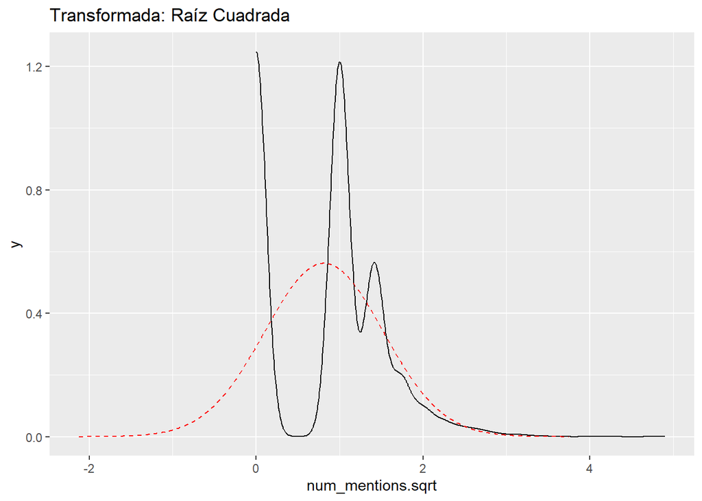

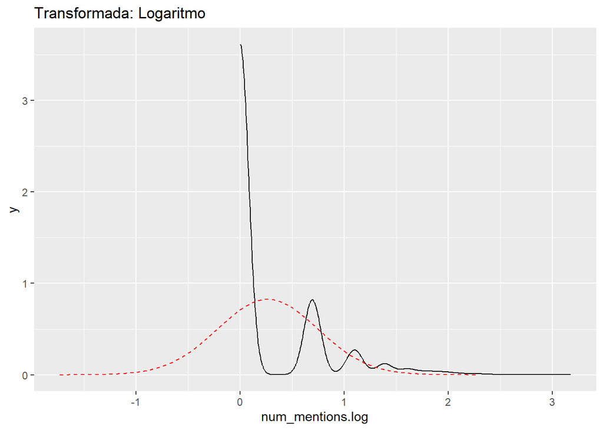

Resultados de los test de skewness para la variable num_mentions.

| original.skewness | raiz.skewness | log.skewness |
| --- | --- | --- |
| 3.265918 | 0.3203965 | 1.814348 |

#### num_emojis

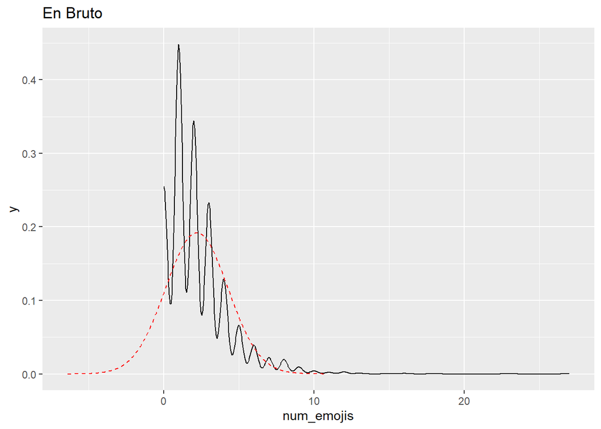

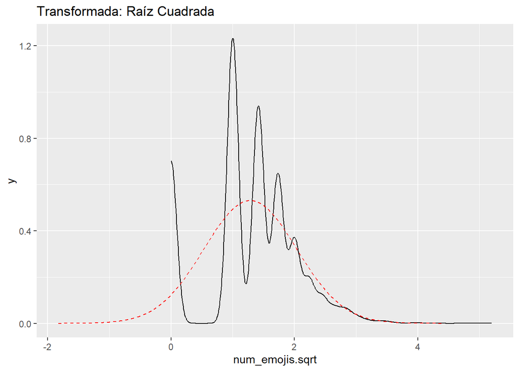

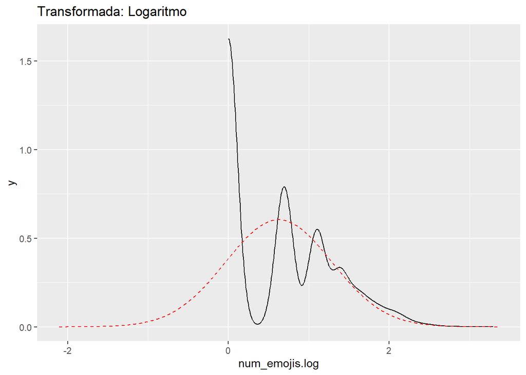

Resultados de los test de skewness para la variable num_emojis.

| original.skewness | raiz.skewness | log.skewness |
| --- | --- | --- |
| 2.230264 | -0.0469595 | 0.6183269 |

#### rostros

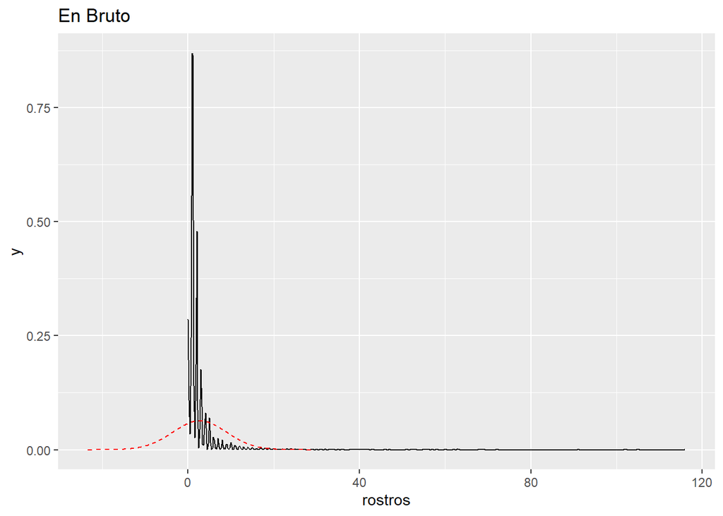

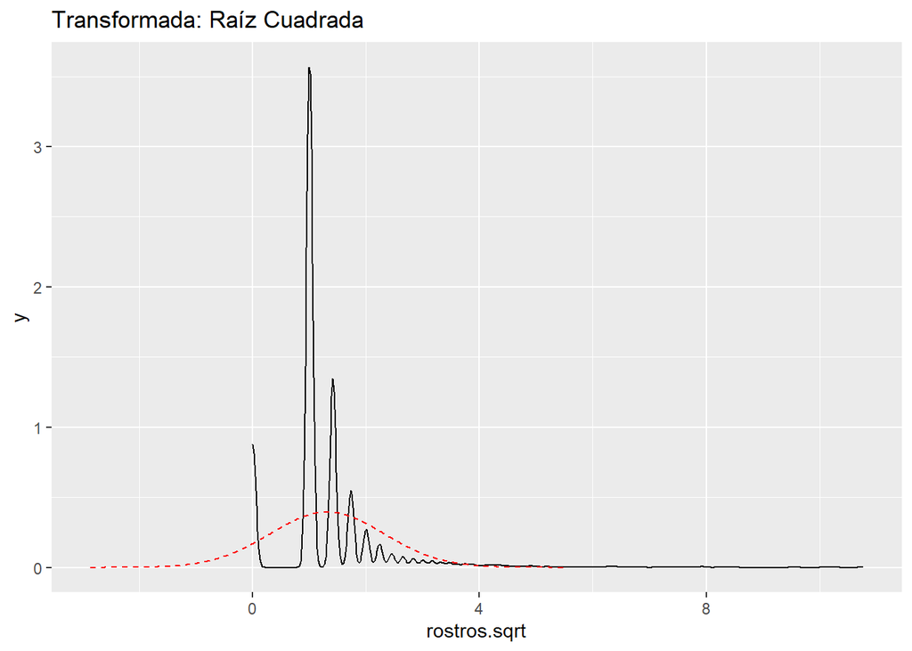

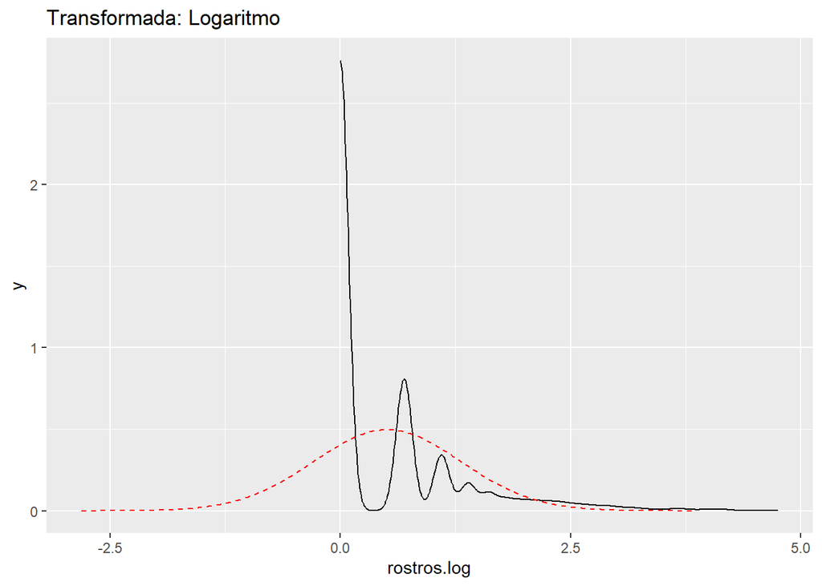

Resultados de los test de skewness para la variable rostros.

| original.skewness | raiz.skewness | log.skewness |
| --- | --- | --- |
| 8.413501 | 2.885777 | 1.871198 |

#### word_count

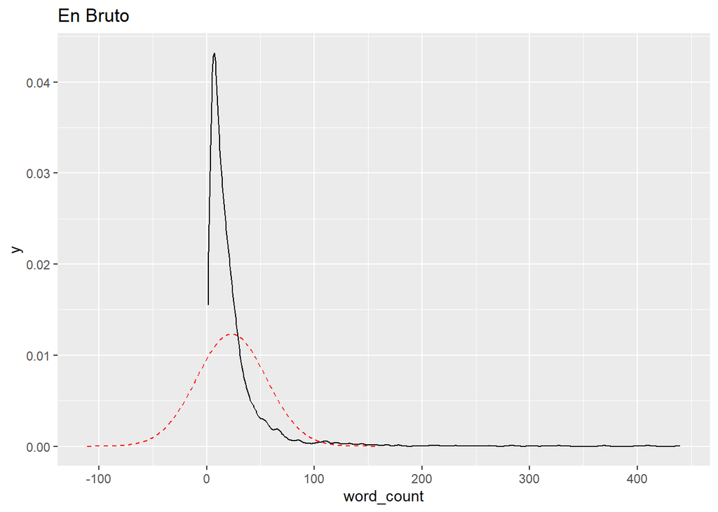

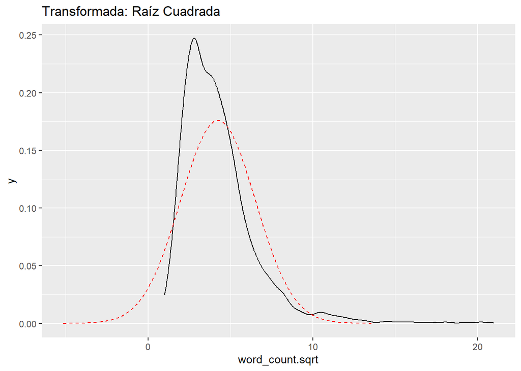

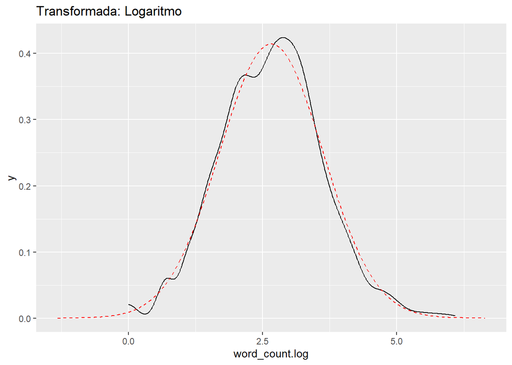

Resultados de los test de skewness para la variable word_count.

| original.skewness | raiz.skewness | log.skewness |
| --- | --- | --- |
| 5.739044 | 2.129672 | 0.1090851 |

#### tone_pos

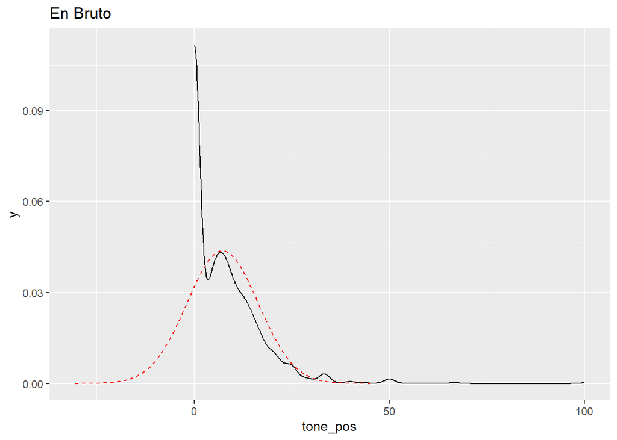

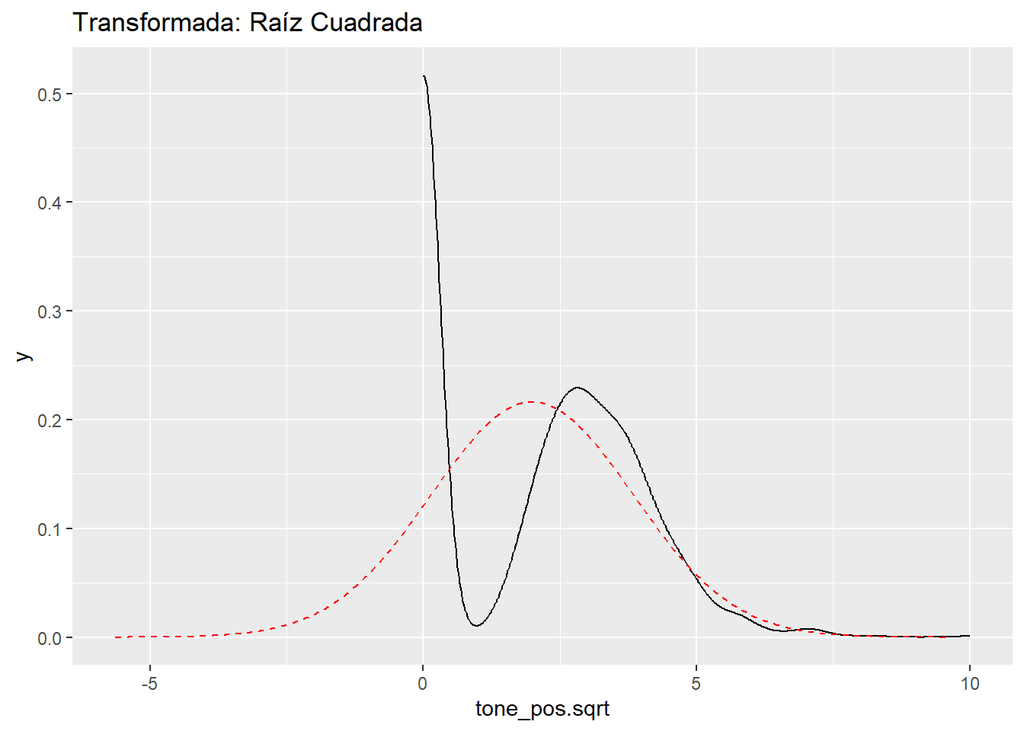

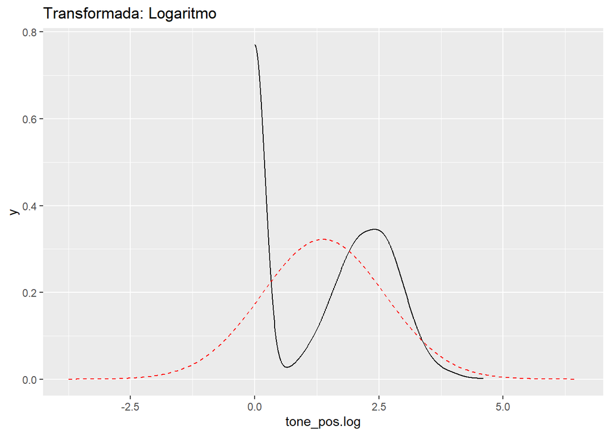

Resultados de los test de skewness para la variable tone_pos.

| original.skewness | raiz.skewness | log.skewness |
| --- | --- | --- |
| 2.390241 | 0.3160892 | 0.0516177 |

#### tone_neg

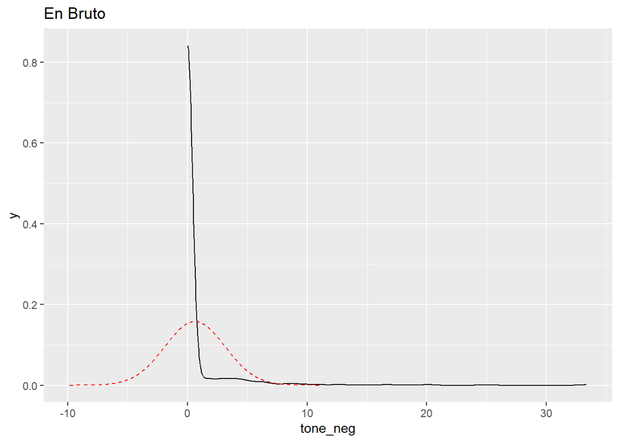

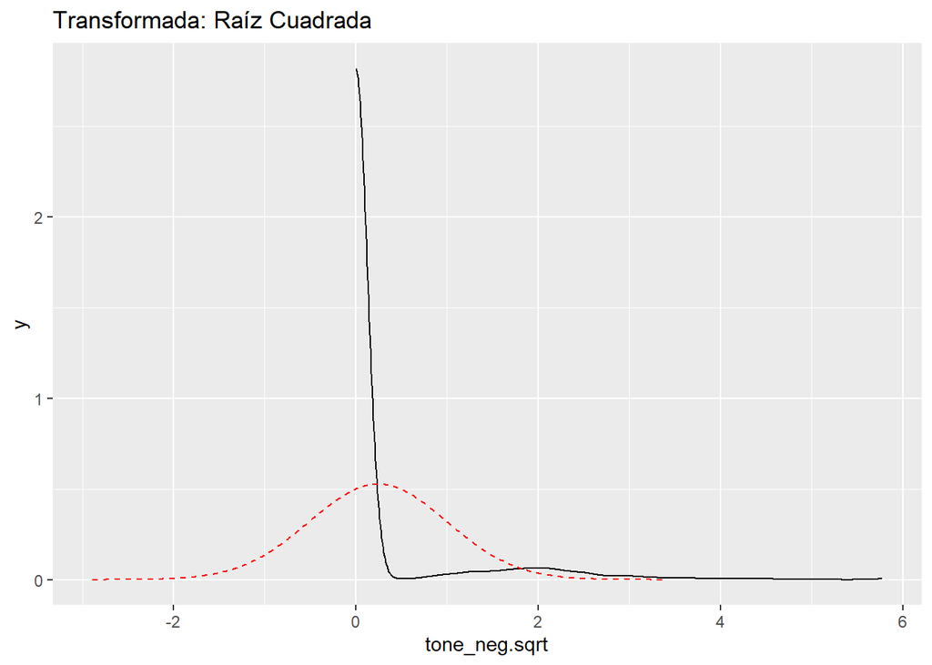

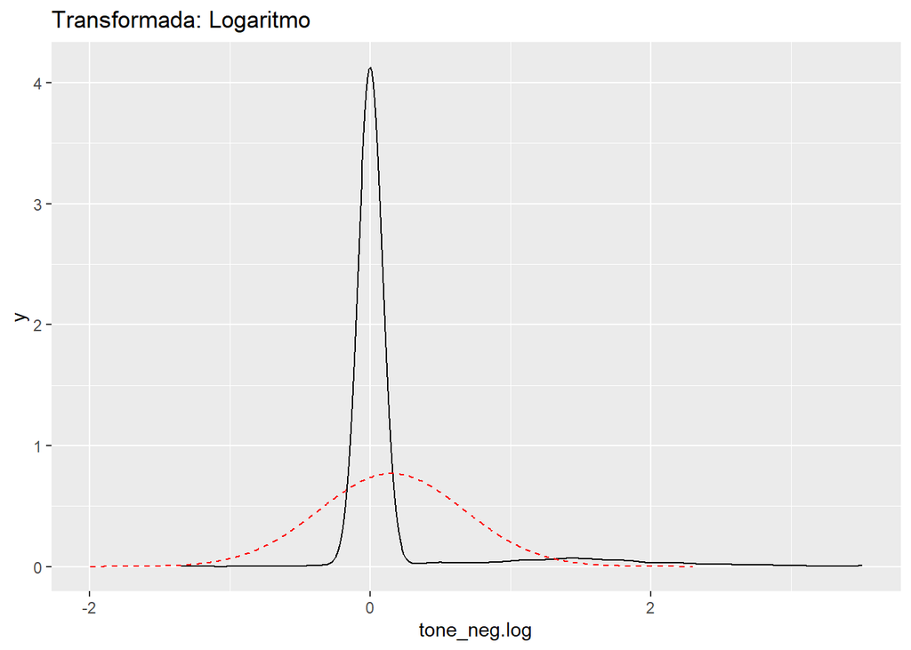

Resultados de los test de skewness para la variable tone_neg.

| original.skewness | raiz.skewness | log.skewness |
| --- | --- | --- |
| 6.835 | 3.474716 | 3.529431 |

#### emo_pos

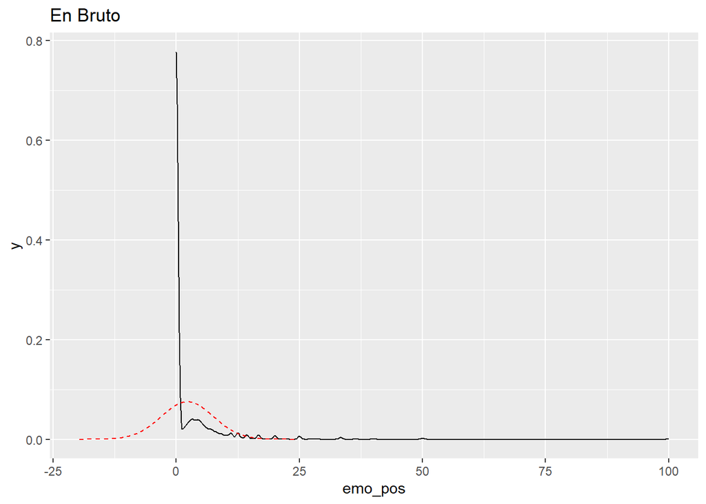

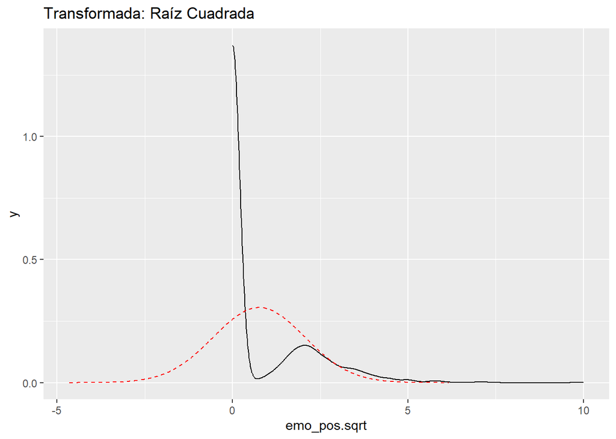

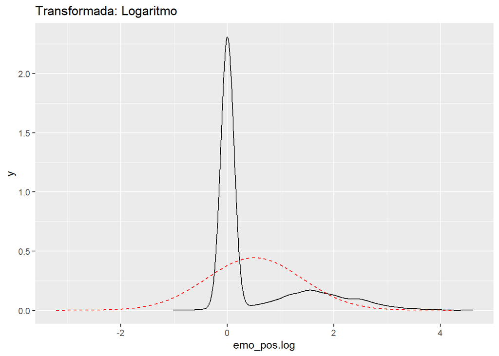

Resultados de los test de skewness para la variable emo_pos.

| original.skewness | raiz.skewness | log.skewness |
| --- | --- | --- |
| 4.951594 | 1.684797 | 1.546981 |

#### emo_neg

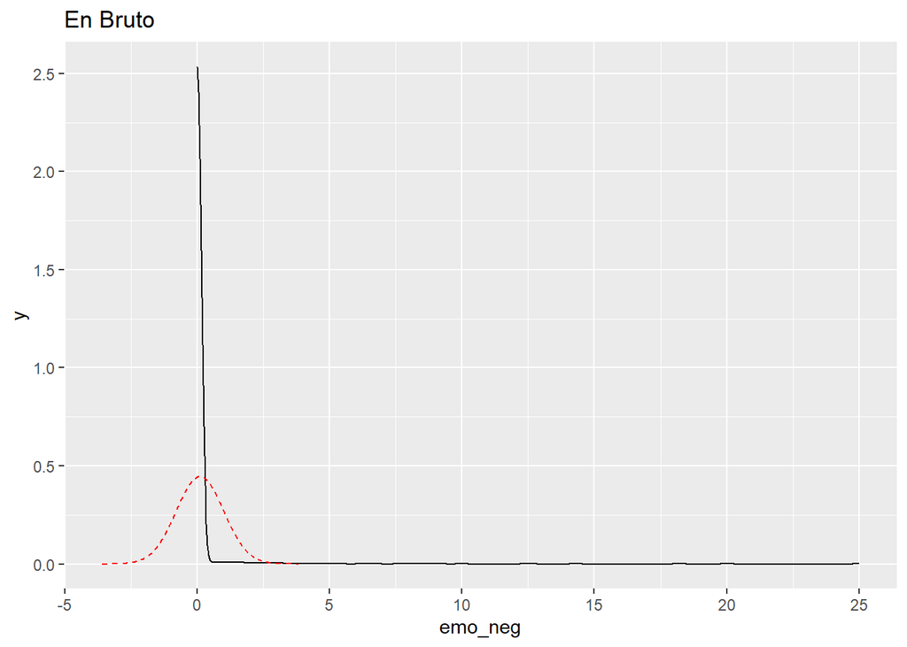

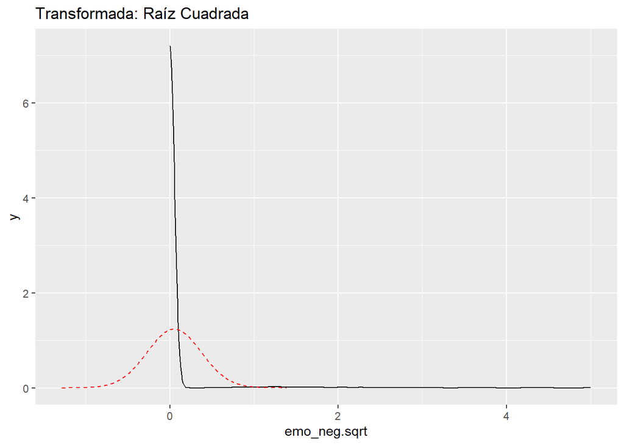

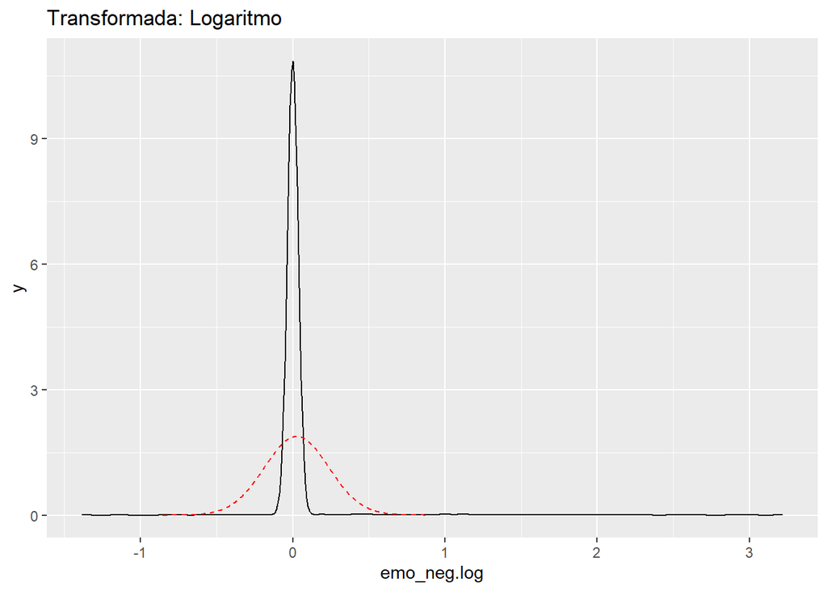

Resultados de los test de skewness para la variable emo_neg.

| original.skewness | raiz.skewness | log.skewness |
| --- | --- | --- |
| 14.81648 | 7.634305 | 8.429521 |

#### prosocial

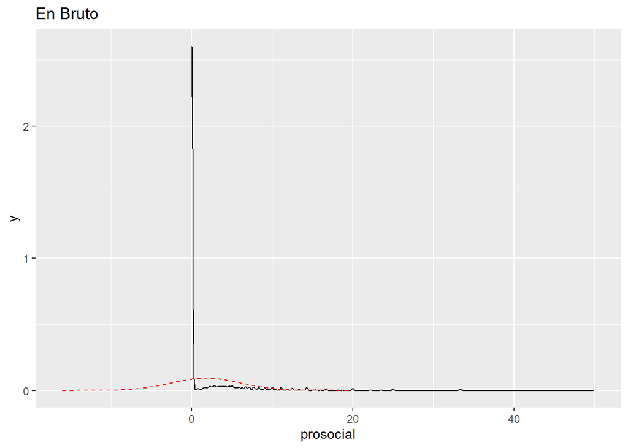

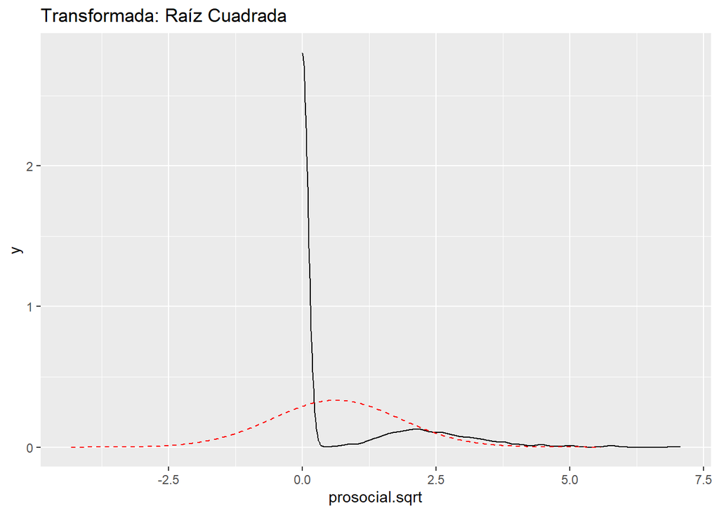

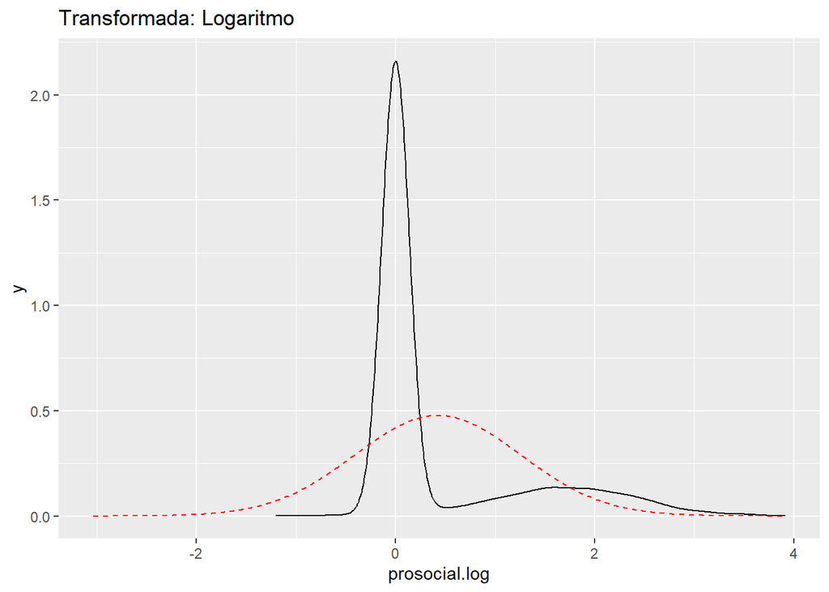

Resultados de los test de skewness para la variable prosocial.

| original.skewness | raiz.skewness | log.skewness |
| --- | --- | --- |
| 3.939468 | 1.780346 | 1.725515 |

#### polite

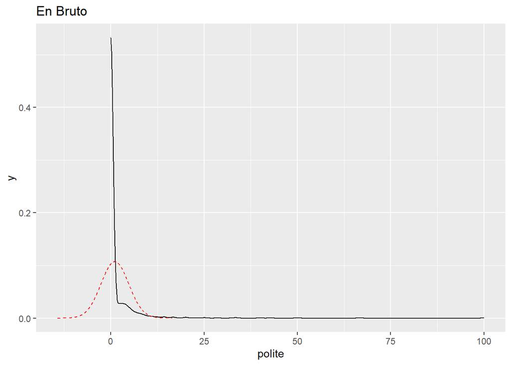

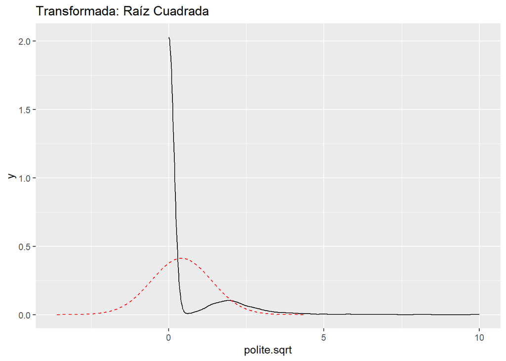

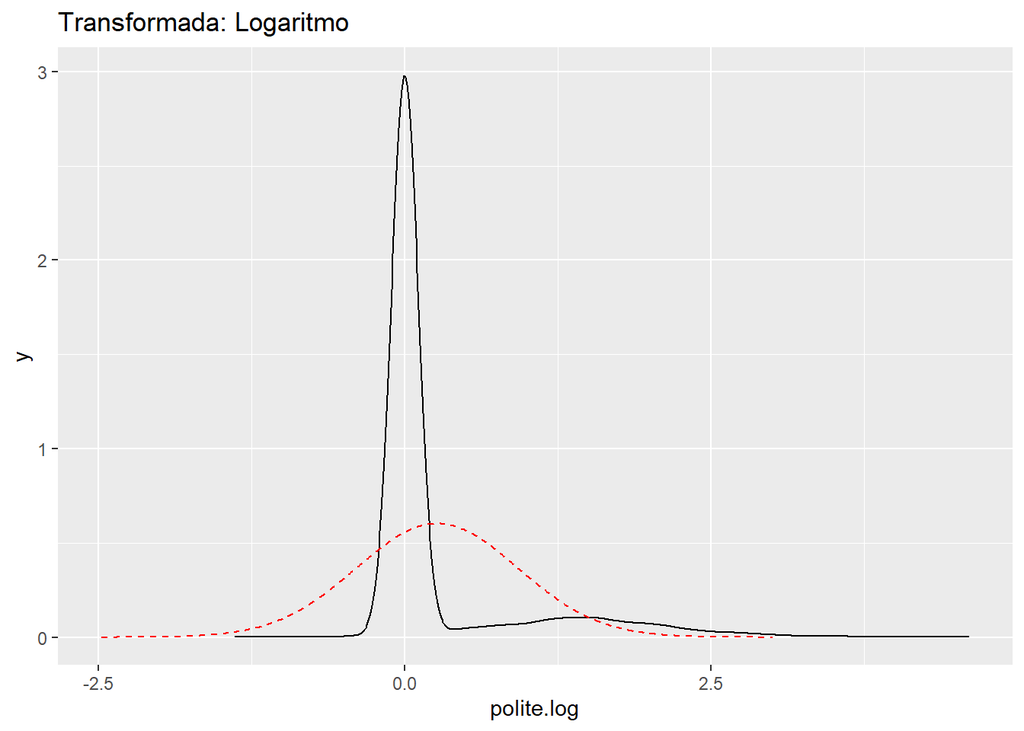

Resultados de los test de skewness para la variable polite.

| original.skewness | raiz.skewness | log.skewness |
| --- | --- | --- |
| 9.449507 | 2.673628 | 2.519909 |

#### Lifestyle

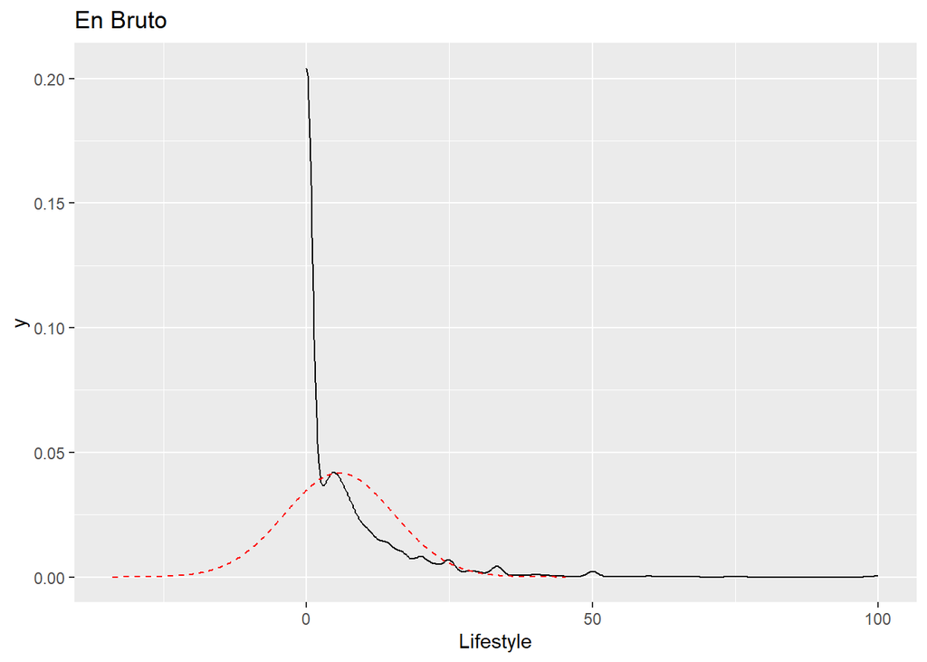

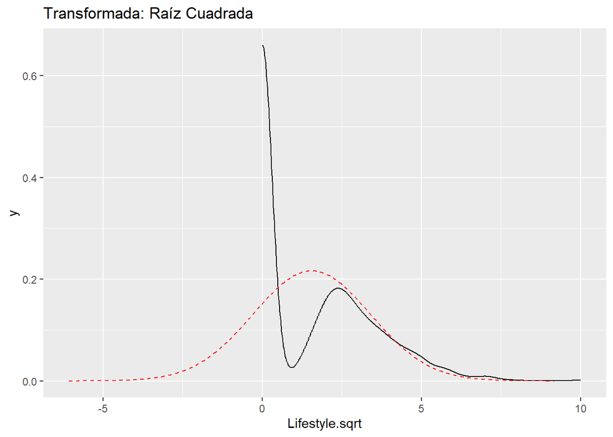

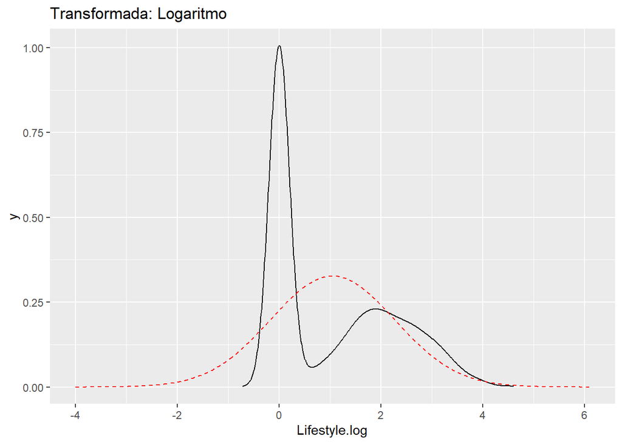

Resultados de los test de skewness para la variable Lifestyle.

| original.skewness | raiz.skewness | log.skewness |
| --- | --- | --- |
| 3.140823 | 0.906837 | 0.6212445 |

#### health

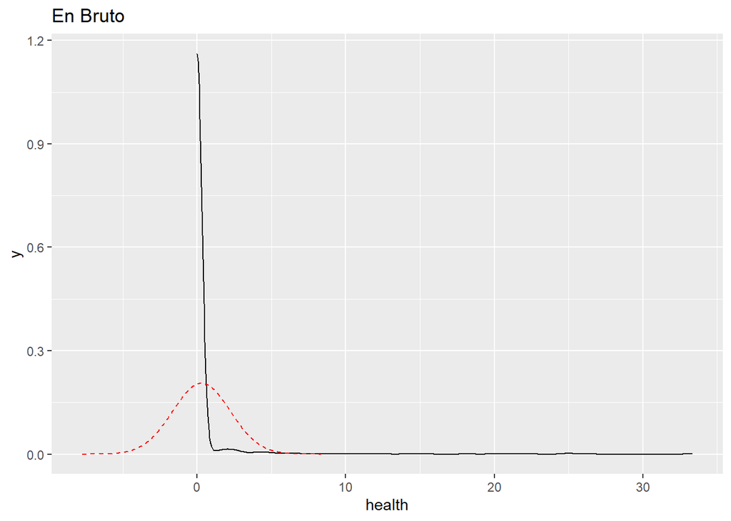

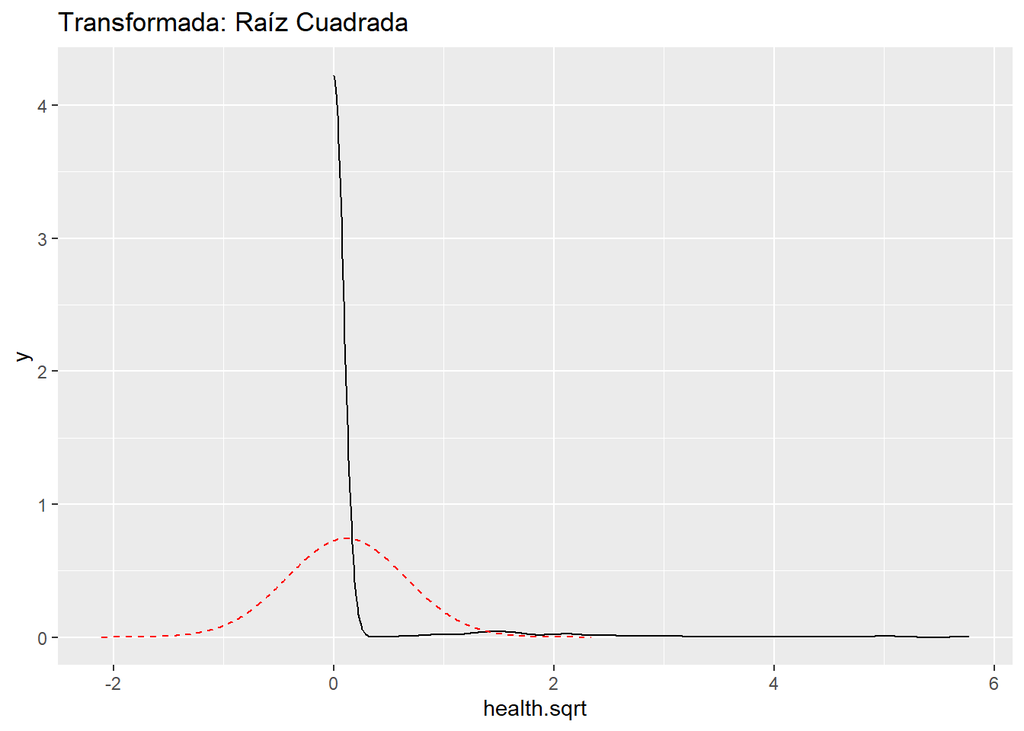

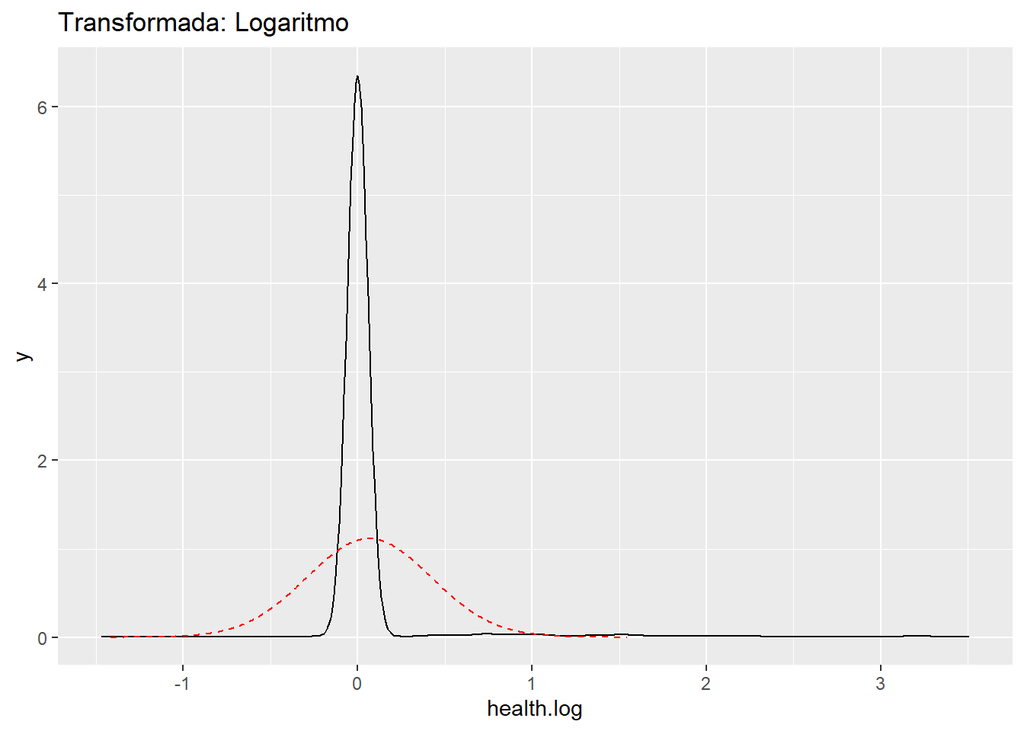

Resultados de los test de skewness para la variable health.

| original.skewness | raiz.skewness | log.skewness |
| --- | --- | --- |
| 10.40618 | 5.79763 | 5.900361 |

A la vista de estos resultados, nos vamos a quedar con las siguientes variables continuas:

- likes.log
- comentarios.log
- Puntos.sqrt
- Edad
- publicaciones.log [aunque la sqrt también está bien, elegiríamos la log por seguir el mismo criterio que con las siguientes variables y no distorsionar los valores]
- followers.log
- following.log [para no distorsionar los valores]
- num_hashtags [kurtosis = 4,05]
- num_menciones [kurtosis = 4,35]
- num_emojis [kurtosis = 2,43]
- rostros.sqrt [aquí el problema es que el máximo es de 116, y esto distorsiona]
- word_count.sqrt
- tone_pos.sqrt
- tone_neg.sqrt
- emo_pos.sqrt
- emo_neg.sqrt
- prosocial.sqrt
- polite.sqrt
- Lifestyle.sqrt
- health.sqrt

# Evaluación de los modelos

## Modelo 3: Likes + LIWC

### Primera aproximación

```r
formula.likes <- likes.log ~ Puntos.sqrt + Edad + publicaciones.log + followers.log + following.log + Nike + Wilson + Yonex + Adidas + Asics + Head + Australian_Open + Roland_Garros + Wimbledon + US_Open + weekend + video + is_sponsored +  franja_horaria +  word_count.sqrt + num_hashtags + num_mentions + num_emojis  + texto.detectado + tennis.instruments + rostros.sqrt + emocion + tone_pos.sqrt + tone_neg.sqrt + emo_pos.sqrt + emo_neg.sqrt + prosocial.sqrt + polite.sqrt + Lifestyle.sqrt + health.sqrt + (1|username)

# evaluamos el modelo
modelo.likes <- lmer(formula.likes, data=datos, REML=FALSE)

# tabla
tab_model(modelo.likes)
```

|  | likes.log |  |  |
| --- | --- | --- | --- |
| Predictors | Estimates | CI | p |
| (Intercept) | 5.21 | 4.18 – 6.24 | **<0.001** |
| Puntos sqrt | 0.04 | 0.03 – 0.05 | **<0.001** |
| Edad | -0.02 | -0.05 – 0.00 | 0.101 |
| publicaciones log | 0.36 | 0.23 – 0.49 | **<0.001** |
| followers log | -0.01 | -0.06 – 0.04 | 0.662 |
| following log | -0.08 | -0.21 – 0.05 | 0.236 |
| Nike | 1.25 | 0.57 – 1.94 | **<0.001** |
| Wilson | 0.31 | -0.31 – 0.93 | 0.330 |
| Yonex | 0.04 | -0.78 – 0.86 | 0.922 |
| Adidas | 0.75 | -0.23 – 1.73 | 0.132 |
| Asics | 0.67 | -0.14 – 1.49 | 0.106 |
| Head | 1.03 | 0.37 – 1.70 | **0.002** |
| Australian Open | 0.06 | -0.02 – 0.14 | 0.127 |
| Roland Garros | 0.03 | -0.05 – 0.11 | 0.512 |
| Wimbledon | 0.09 | 0.02 – 0.17 | **0.018** |
| US Open | 0.00 | -0.07 – 0.08 | 0.915 |
| weekend | 0.04 | -0.01 – 0.09 | 0.124 |
| video | -0.10 | -0.16 – -0.04 | **0.001** |
| is sponsored [True] | -0.32 | -0.66 – 0.02 | 0.069 |
| franja horaria [Tarde] | 0.03 | -0.03 – 0.09 | 0.377 |
| franja horaria [Noche] | 0.10 | 0.02 – 0.17 | **0.010** |
| word count sqrt | 0.01 | 0.00 – 0.03 | **0.050** |
| num hashtags | -0.02 | -0.03 – -0.01 | **<0.001** |
| num mentions | -0.02 | -0.04 – 0.00 | 0.101 |
| num emojis | 0.01 | -0.01 – 0.02 | 0.451 |
| texto detectado | 0.10 | 0.04 – 0.15 | **0.001** |
| tennis instruments | 0.19 | 0.14 – 0.24 | **<0.001** |
| rostros sqrt | 0.05 | 0.03 – 0.08 | **<0.001** |
| emocion [happy] | 0.07 | -0.00 – 0.13 | 0.055 |
| emocion [surprise] | 0.08 | -0.14 – 0.31 | 0.479 |
| emocion [fear] | 0.03 | -0.06 – 0.11 | 0.531 |
| emocion [disgust] | -0.08 | -0.66 – 0.51 | 0.794 |
| emocion [angry] | 0.04 | -0.04 – 0.12 | 0.340 |
| emocion [sad] | 0.01 | -0.06 – 0.09 | 0.703 |
| tone pos sqrt | 0.02 | -0.00 – 0.03 | 0.095 |
| tone neg sqrt | 0.06 | 0.03 – 0.10 | **0.001** |
| emo pos sqrt | -0.03 | -0.06 – -0.01 | **0.005** |
| emo neg sqrt | 0.09 | 0.00 – 0.17 | **0.038** |
| prosocial sqrt | -0.05 | -0.07 – -0.02 | **0.001** |
| polite sqrt | 0.04 | 0.00 – 0.07 | **0.035** |
| Lifestyle sqrt | 0.02 | 0.01 – 0.03 | **0.006** |
| health sqrt | -0.05 | -0.09 – 0.00 | 0.050 |
| Random Effects |  |  |  |
| σ<sup>2</sup> | 0.59 |  |  |
| τ<sub>00</sub> <sub>username</sub> | 0.86 |  |  |
| ICC | 0.59 |  |  |
| N <sub>username</sub> | 341 |  |  |
| Observations | 4451 |  |  |
| Marginal R<sup>2</sup> / Conditional R<sup>2</sup> | 0.601 / 0.838 |  |  |

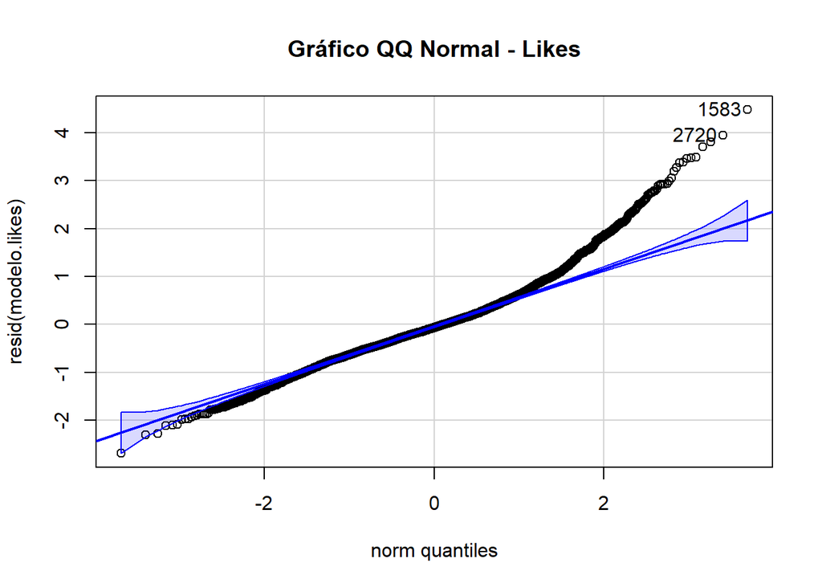

```
## 1583 2720
## 1536 2619
```

```r
#TABLA MODELSUMMARY
tabla1 <- modelsummary(
  modelo.likes,
  estimate = "estimate",
  stars  = c('*' = 0.05, '**' = .01, '***' = .001),
  fmt = 3,
  shape = term ~ model + statistic,
  statistic = c('2.5%' = 'conf.low', '97.5%' = 'conf.high', 'p' = 'p.value'),
  conf_level = 0.95,
  output = "data.frame"
)

#RENOMBRADO COLUMNAS
colnames(tabla1)[2:6] <- c("Predictors","Estimates", "2.5%", "97.5%", "p")

N <- sum(tabla1[4]!="", na.rm = TRUE)
tabla1$CI <- paste0('[', tabla1$`2.5%`, ', ', tabla1$`97.5%`, ']')

tabla1$CI[(N+1):nrow(tabla1)] <- ''

tabla1$Predictors[2:N] <- c("Puntos ATP (Trf Raíz)", "Edad" , "Publicaciones (Trf Log)" , "Followers (Trf Log)" , "Following (Trf Log)" , "Nike" , "Wilson" , "Yonex" , "Adidas" , "Asics" , "Head" , "Australian Open" , "Roland Garros" , "Wimbledon" , "US Open" , "Fin de Semana" , "Video" , "Patrocinado" ,  "Tarde" , "Noche", "Nº Palabras (Trf Raíz)" , "Nº Hashtags" , "Nº Menciones" , "Nº Emojis"  , "Texto en Img" , "Instrumentos de Tenis" , "Nº Rostros (Trf Raíz)", "Felicidad", "Sorpresa", "Miedo", "Asco", "Enfado", "Tristeza", "Tono pos. (Trf Raíz)", "Tono neg. (Trf Raíz)", "Emoción pos. (Trf Raíz)", "Emoción neg. (Trf Raíz)", "Prosocial (Trf Raíz)", "Respetuoso (Trf Raíz)", "Estilo de vida (Trf Raíz)", "Salud (Trf Raíz)")

#SELECCIÓN COLUMNAS
tabla1 <- tabla1 %>% select('Predictors', 'Estimates', 'CI', 'p')
tabla1$Predictors[46] <- "R2 Marg./R2 Cond."
tabla1$Estimates[46] <- paste(tabla1$Estimates[46],tabla1$Estimates[47], sep = '/')
tabla1 <- tabla1[-c(47,48,49,51),]

#SEPARADO DE TABLA

tabla1.1 <- tabla1[1:34,]
tabla1.2 <- tabla1[35:nrow(tabla1),]
rownames(tabla1.2) <- NULL

tabla1_latex <- kable(tabla1, "latex", booktabs = TRUE, align = "lccc", caption = "Tabla del Modelo 3", row.names = FALSE) %>%
  kable_styling(
    latex_options = c("striped", "hold_position",  "scale_down"),
    full_width = FALSE,
    position = "center",
    font_size = 9
  ) %>%
  add_header_above(c(" " = 1, "Likes (Trf Log)" = 3)) %>%
  pack_rows("Usuario", 2, 6, italic = TRUE, bold = FALSE) %>%
  pack_rows("Marcas", 7, 12, italic = TRUE, bold = FALSE) %>%
  pack_rows("Torneos", 13, 16, italic = TRUE, bold = FALSE) %>%
  pack_rows("Post", 17, 19, italic = TRUE, bold = FALSE) %>%
  pack_rows("Franja (ref = mañana)", 20, 21, italic = TRUE, bold = FALSE) %>%
  pack_rows("Texto", 22 , 25, italic = TRUE, bold = FALSE) %>%
  pack_rows("Imagen", 26 , 28, italic = TRUE, bold = FALSE) %>%
  pack_rows("Emoción Imagen (ref = neutral)", 29, 34, italic = TRUE, bold = FALSE) %>%
  pack_rows("Análisis Textual", 35 , 42, italic = TRUE, bold = FALSE) %>%
  row_spec(42, extra_latex_after = "\\midrule") %>%
  pack_rows("SD de Efectos Aleatorios", 43, 44, italic = TRUE, bold = FALSE) %>%
  row_spec(44, extra_latex_after = "\\midrule") %>%
  footnote(
    general = "* p<0.05; ** p<0.01; *** p<0.001",
    footnote_as_chunk = TRUE,
    escape = FALSE
  )%>%
  column_spec(2:7, width = "2cm")

# Gráfico QQ Normal
qqPlot(resid(modelo.likes), main = 'Gráfico QQ Normal - Likes')
```

A la vista de este resultado, hacemos un tratamiento de los outliers, para intentar mejorar este resultado.

### Modelo sin outliers

```r
# sacamos los outliers
outliers <- outlierTest(modelo.likes)
indices.outliers <- as.numeric(names(outliers$rstudent))
```

```r
# evaluamos el nuevo modelo
modelo.likes.sinoutliers <- lmer(formula.likes, data = datos[-indices.outliers, ], REML=FALSE)

# tabla
tab_model(modelo.likes.sinoutliers)
```

|  | likes.log |  |  |
| --- | --- | --- | --- |
| Predictors | Estimates | CI | p |
| (Intercept) | 5.21 | 4.18 – 6.24 | **<0.001** |
| Puntos sqrt | 0.04 | 0.03 – 0.05 | **<0.001** |
| Edad | -0.02 | -0.05 – 0.00 | 0.103 |
| publicaciones log | 0.36 | 0.23 – 0.49 | **<0.001** |
| followers log | -0.01 | -0.06 – 0.04 | 0.671 |
| following log | -0.08 | -0.21 – 0.05 | 0.235 |
| Nike | 1.25 | 0.57 – 1.94 | **<0.001** |
| Wilson | 0.31 | -0.31 – 0.93 | 0.328 |
| Yonex | 0.04 | -0.78 – 0.86 | 0.919 |
| Adidas | 0.75 | -0.23 – 1.73 | 0.132 |
| Asics | 0.67 | -0.15 – 1.49 | 0.107 |
| Head | 1.03 | 0.37 – 1.70 | **0.002** |
| Australian Open | 0.06 | -0.02 – 0.14 | 0.129 |
| Roland Garros | 0.02 | -0.06 – 0.11 | 0.561 |
| Wimbledon | 0.09 | 0.02 – 0.17 | **0.017** |
| US Open | 0.01 | -0.07 – 0.08 | 0.876 |
| weekend | 0.04 | -0.01 – 0.09 | 0.158 |
| video | -0.10 | -0.16 – -0.04 | **0.001** |
| is sponsored [True] | -0.32 | -0.66 – 0.02 | 0.068 |
| franja horaria [Tarde] | 0.03 | -0.04 – 0.09 | 0.407 |
| franja horaria [Noche] | 0.10 | 0.02 – 0.17 | **0.010** |
| word count sqrt | 0.01 | -0.00 – 0.03 | 0.052 |
| num hashtags | -0.02 | -0.03 – -0.01 | **<0.001** |
| num mentions | -0.02 | -0.04 – 0.00 | 0.082 |
| num emojis | 0.01 | -0.01 – 0.02 | 0.428 |
| texto detectado | 0.10 | 0.04 – 0.15 | **0.001** |
| tennis instruments | 0.19 | 0.14 – 0.24 | **<0.001** |
| rostros sqrt | 0.05 | 0.03 – 0.08 | **<0.001** |
| emocion [happy] | 0.06 | -0.00 – 0.13 | 0.069 |
| emocion [surprise] | 0.08 | -0.14 – 0.31 | 0.464 |
| emocion [fear] | 0.03 | -0.06 – 0.11 | 0.531 |
| emocion [disgust] | -0.08 | -0.66 – 0.50 | 0.784 |
| emocion [angry] | 0.04 | -0.04 – 0.12 | 0.335 |
| emocion [sad] | 0.01 | -0.06 – 0.09 | 0.690 |
| tone pos sqrt | 0.01 | -0.00 – 0.03 | 0.097 |
| tone neg sqrt | 0.06 | 0.03 – 0.10 | **0.001** |
| emo pos sqrt | -0.03 | -0.06 – -0.01 | **0.004** |
| emo neg sqrt | 0.09 | 0.01 – 0.17 | **0.035** |
| prosocial sqrt | -0.05 | -0.07 – -0.02 | **0.001** |
| polite sqrt | 0.04 | 0.00 – 0.07 | **0.037** |
| Lifestyle sqrt | 0.02 | 0.01 – 0.03 | **0.007** |
| health sqrt | -0.05 | -0.09 – -0.00 | **0.050** |
| Random Effects |  |  |  |
| σ<sup>2</sup> | 0.58 |  |  |
| τ<sub>00</sub> <sub>username</sub> | 0.86 |  |  |
| ICC | 0.59 |  |  |
| N <sub>username</sub> | 341 |  |  |
| Observations | 4443 |  |  |
| Marginal R<sup>2</sup> / Conditional R<sup>2</sup> | 0.602 / 0.839 |  |  |

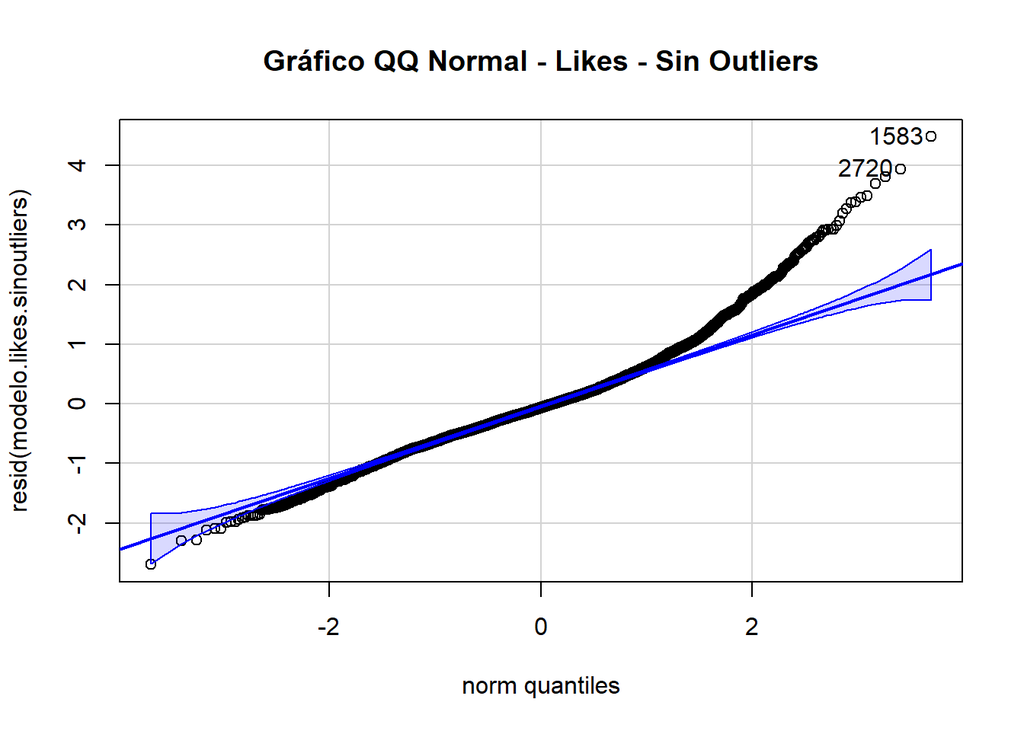

```
## 1583 2720
## 1534 2615
```

```r
#TABLA MODELSUMMARY
tabla2 <- modelsummary(
  modelo.likes.sinoutliers,
  estimate = "estimate",
  stars  = c('*' = 0.05, '**' = .01, '***' = .001),
  fmt = 3,
  shape = term ~ model + statistic,
  statistic = c('2.5%' = 'conf.low', '97.5%' = 'conf.high', 'p' = 'p.value'),
  conf_level = 0.95,
  output = "data.frame"
)

#RENOMBRADO COLUMNAS
colnames(tabla2)[2:6] <- c("Predictors","Estimates", "2.5%", "97.5%", "p")

N <- sum(tabla2[4]!="", na.rm = TRUE)
tabla2$CI <- paste0('[', tabla2$`2.5%`, ', ', tabla2$`97.5%`, ']')

tabla2$CI[(N+1):nrow(tabla2)] <- ''

tabla2$Predictors[2:N] <- c("Puntos ATP (Trf Raíz)", "Edad" , "Publicaciones (Trf Log)" , "Followers (Trf Log)" , "Following (Trf Log)" , "Nike" , "Wilson" , "Yonex" , "Adidas" , "Asics" , "Head" , "Australian Open" , "Roland Garros" , "Wimbledon" , "US Open" , "Fin de Semana" , "Video" , "Patrocinado" ,  "Tarde" , "Noche", "Nº Palabras (Trf Raíz)" , "Nº Hashtags" , "Nº Menciones" , "Nº Emojis"  , "Texto en Img" , "Instrumentos de Tenis" , "Nº Rostros (Trf Raíz)", "Felicidad", "Sorpresa", "Miedo", "Asco", "Enfado", "Tristeza", "Tono pos. (Trf Raíz)", "Tono neg. (Trf Raíz)", "Emoción pos. (Trf Raíz)", "Emoción neg. (Trf Raíz)", "Prosocial (Trf Raíz)", "Respetuoso (Trf Raíz)", "Estilo de vida (Trf Raíz)", "Salud (Trf Raíz)")

#SELECCIÓN COLUMNAS
tabla2 <- tabla2 %>% select('Predictors', 'Estimates', 'CI', 'p')
tabla2$Predictors[46] <- "R2 Marg./R2 Cond."
tabla2$Estimates[46] <- paste(tabla2$Estimates[46],tabla2$Estimates[47], sep = '/')
tabla2 <- tabla2[-c(47,48,49,51),]

#SEPARADO DE TABLA

tabla2.1 <- tabla2[1:34,]
tabla2.2 <- tabla2[35:nrow(tabla2),]
rownames(tabla2.2) <- NULL

tabla2_latex <- kable(tabla2, "latex", booktabs = TRUE, align = "lccc", caption = "Tabla del Modelo 3 sin outliers",
  row.names = FALSE) %>%
  kable_styling(
    latex_options = c("striped", "hold_position",  "scale_down"),
    full_width = FALSE,
    position = "center",
    font_size = 9
  ) %>%
  add_header_above(c(" " = 1, "Likes (Trf Log) sin outliers" = 3)) %>%
  pack_rows("Usuario", 2, 6, italic = TRUE, bold = FALSE) %>%
  pack_rows("Marcas", 7, 12, italic = TRUE, bold = FALSE) %>%
  pack_rows("Torneos", 13, 16, italic = TRUE, bold = FALSE) %>%
  pack_rows("Post", 17, 19, italic = TRUE, bold = FALSE) %>%
  pack_rows("Franja (ref = mañana)", 20, 21, italic = TRUE, bold = FALSE) %>%
  pack_rows("Texto", 22 , 25, italic = TRUE, bold = FALSE) %>%
  pack_rows("Imagen", 26 , 28, italic = TRUE, bold = FALSE) %>%
  pack_rows("Emoción Imagen (ref = neutral)", 29, 34, italic = TRUE, bold = FALSE) %>%
  pack_rows("Análisis Textual", 35 , 42, italic = TRUE, bold = FALSE) %>%
  row_spec(42, extra_latex_after = "\\midrule") %>%
  pack_rows("SD de Efectos Aleatorios", 43, 44, italic = TRUE, bold = FALSE) %>%
  row_spec(44, extra_latex_after = "\\midrule") %>%
  footnote(
    general = "* p<0.05; ** p<0.01; *** p<0.001",
    footnote_as_chunk = TRUE,
    escape = FALSE
  )%>%
  column_spec(2:7, width = "2cm")

# Gráfico QQ Normal
qqPlot(resid(modelo.likes.sinoutliers), main = 'Gráfico QQ Normal - Likes - Sin Outliers')
```

## Modelo 4: Comentarios

### Primera aproximación

```r
formula.comentarios <- comentarios.log ~ Puntos.sqrt + Edad + publicaciones.log + followers.log + following.log + Nike + Wilson + Yonex + Adidas + Asics + Head + Australian_Open + Roland_Garros + Wimbledon + US_Open + weekend + video + is_sponsored +  franja_horaria +  word_count.sqrt + num_hashtags + num_mentions + num_emojis  + texto.detectado + tennis.instruments + rostros.sqrt + emocion + tone_pos.sqrt + tone_neg.sqrt + emo_pos.sqrt + emo_neg.sqrt + prosocial.sqrt + polite.sqrt + Lifestyle.sqrt + health.sqrt + (1|username)

# evaluamos el modelo
modelo.comentarios <- lmer(formula.comentarios, data=datos, REML=FALSE)

# tabla
tab_model(modelo.comentarios)
```

|  | comentarios.log |  |  |
| --- | --- | --- | --- |
| Predictors | Estimates | CI | p |
| (Intercept) | 1.23 | 0.10 – 2.36 | **0.033** |
| Puntos sqrt | 0.03 | 0.02 – 0.04 | **<0.001** |
| Edad | -0.01 | -0.04 – 0.02 | 0.416 |
| publicaciones log | 0.05 | -0.09 – 0.20 | 0.465 |
| followers log | 0.05 | 0.00 – 0.10 | **0.037** |
| following log | 0.14 | -0.00 – 0.28 | 0.056 |
| Nike | 0.89 | 0.15 – 1.62 | **0.019** |
| Wilson | -0.02 | -0.69 – 0.65 | 0.947 |
| Yonex | 0.03 | -0.86 – 0.92 | 0.941 |
| Adidas | 0.67 | -0.40 – 1.74 | 0.220 |
| Asics | 0.88 | -0.00 – 1.75 | 0.050 |
| Head | 0.61 | -0.12 – 1.33 | 0.100 |
| Australian Open | 0.09 | -0.01 – 0.20 | 0.088 |
| Roland Garros | 0.05 | -0.06 – 0.16 | 0.365 |
| Wimbledon | 0.12 | 0.02 – 0.22 | **0.024** |
| US Open | 0.00 | -0.10 – 0.10 | 0.958 |
| weekend | 0.03 | -0.04 – 0.10 | 0.350 |
| video | -0.13 | -0.20 – -0.05 | **0.001** |
| is sponsored [True] | -0.31 | -0.76 – 0.14 | 0.175 |
| franja horaria [Tarde] | 0.03 | -0.05 – 0.11 | 0.498 |
| franja horaria [Noche] | 0.05 | -0.05 – 0.15 | 0.335 |
| word count sqrt | 0.05 | 0.03 – 0.06 | **<0.001** |
| num hashtags | -0.03 | -0.04 – -0.02 | **<0.001** |
| num mentions | -0.01 | -0.04 – 0.01 | 0.368 |
| num emojis | 0.00 | -0.01 – 0.02 | 0.770 |
| texto detectado | 0.10 | 0.02 – 0.17 | **0.011** |
| tennis instruments | 0.16 | 0.10 – 0.23 | **<0.001** |
| rostros sqrt | 0.01 | -0.02 – 0.05 | 0.422 |
| emocion [happy] | 0.09 | 0.00 – 0.18 | **0.043** |
| emocion [surprise] | 0.01 | -0.28 – 0.31 | 0.933 |
| emocion [fear] | 0.03 | -0.08 – 0.14 | 0.568 |
| emocion [disgust] | -0.46 | -1.23 – 0.31 | 0.241 |
| emocion [angry] | 0.06 | -0.05 – 0.17 | 0.259 |
| emocion [sad] | 0.04 | -0.06 – 0.13 | 0.428 |
| tone pos sqrt | -0.00 | -0.02 – 0.02 | 1.000 |
| tone neg sqrt | 0.01 | -0.03 – 0.06 | 0.625 |
| emo pos sqrt | -0.01 | -0.04 – 0.02 | 0.452 |
| emo neg sqrt | 0.14 | 0.03 – 0.24 | **0.013** |
| prosocial sqrt | -0.04 | -0.08 – -0.01 | **0.022** |
| polite sqrt | 0.05 | 0.00 – 0.09 | **0.045** |
| Lifestyle sqrt | 0.00 | -0.02 – 0.02 | 0.838 |
| health sqrt | -0.04 | -0.10 – 0.02 | 0.199 |
| Random Effects |  |  |  |
| σ<sup>2</sup> | 1.02 |  |  |
| τ<sub>00</sub> <sub>username</sub> | 0.97 |  |  |
| ICC | 0.49 |  |  |
| N <sub>username</sub> | 341 |  |  |
| Observations | 4451 |  |  |
| Marginal R<sup>2</sup> / Conditional R<sup>2</sup> | 0.352 / 0.668 |  |  |

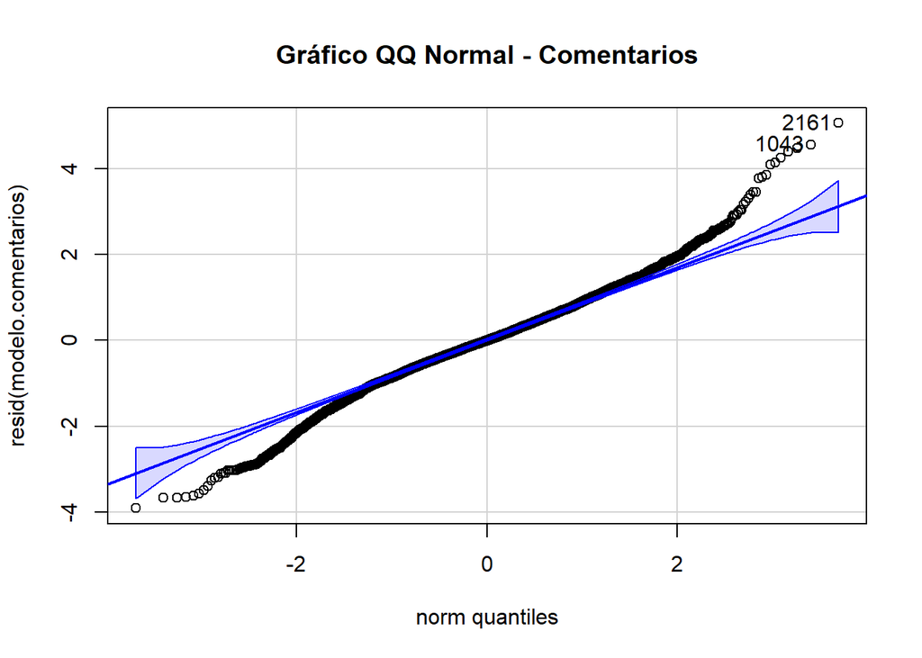

```
## 2161 1043
## 2080 1002
```

```r
#TABLA MODELSUMMARY
tabla3 <- modelsummary(
  modelo.comentarios,
  estimate = "estimate",
  stars  = c('*' = 0.05, '**' = .01, '***' = .001),
  fmt = 3,
  shape = term ~ model + statistic,
  statistic = c('2.5%' = 'conf.low', '97.5%' = 'conf.high', 'p' = 'p.value'),
  conf_level = 0.95,
  output = "data.frame"
)

#RENOMBRADO COLUMNAS
colnames(tabla3)[2:6] <- c("Predictors","Estimates", "2.5%", "97.5%", "p")

N <- sum(tabla3[4]!="", na.rm = TRUE)
tabla3$CI <- paste0('[', tabla3$`2.5%`, ', ', tabla3$`97.5%`, ']')

tabla3$CI[(N+1):nrow(tabla3)] <- ''

tabla3$Predictors[2:N] <- c("Puntos ATP (Trf Raíz)", "Edad" , "Publicaciones (Trf Log)" , "Followers (Trf Log)" , "Following (Trf Log)" , "Nike" , "Wilson" , "Yonex" , "Adidas" , "Asics" , "Head" , "Australian Open" , "Roland Garros" , "Wimbledon" , "US Open" , "Fin de Semana" , "Video" , "Patrocinado" ,  "Tarde" , "Noche", "Nº Palabras (Trf Raíz)" , "Nº Hashtags" , "Nº Menciones" , "Nº Emojis"  , "Texto en Img" , "Instrumentos de Tenis" , "Nº Rostros (Trf Raíz)", "Felicidad", "Sorpresa", "Miedo", "Asco", "Enfado", "Tristeza", "Tono pos. (Trf Raíz)", "Tono neg. (Trf Raíz)", "Emoción pos. (Trf Raíz)", "Emoción neg. (Trf Raíz)", "Prosocial (Trf Raíz)", "Respetuoso (Trf Raíz)", "Estilo de vida (Trf Raíz)", "Salud (Trf Raíz)")

#SELECCIÓN COLUMNAS
tabla3 <- tabla3 %>% select('Predictors', 'Estimates', 'CI', 'p')
tabla3$Predictors[46] <- "R2 Marg./R2 Cond."
tabla3$Estimates[46] <- paste(tabla3$Estimates[46],tabla3$Estimates[47], sep = '/')
tabla3 <- tabla3[-c(47,48,49,51),]

#SEPARADO DE TABLA

tabla3.1 <- tabla3[1:34,]
tabla3.2 <- tabla3[35:nrow(tabla3),]
rownames(tabla3.2) <- NULL

tabla3_latex <- kable(tabla3, "latex", booktabs = TRUE, align = "lccc", caption = "Tabla del Modelo 4",
  row.names = FALSE) %>%
  kable_styling(
    latex_options = c("striped", "hold_position",  "scale_down"),
    full_width = FALSE,
    position = "center",
    font_size = 9
  ) %>%
  add_header_above(c(" " = 1, "Comentarios (Trf Log)" = 3)) %>%
  pack_rows("Usuario", 2, 6, italic = TRUE, bold = FALSE) %>%
  pack_rows("Marcas", 7, 12, italic = TRUE, bold = FALSE) %>%
  pack_rows("Torneos", 13, 16, italic = TRUE, bold = FALSE) %>%
  pack_rows("Post", 17, 19, italic = TRUE, bold = FALSE) %>%
  pack_rows("Franja (ref = mañana)", 20, 21, italic = TRUE, bold = FALSE) %>%
  pack_rows("Texto", 22 , 25, italic = TRUE, bold = FALSE) %>%
  pack_rows("Imagen", 26 , 28, italic = TRUE, bold = FALSE) %>%
  pack_rows("Emoción Imagen (ref = neutral)", 29, 34, italic = TRUE, bold = FALSE) %>%
  pack_rows("Análisis Textual", 35 , 42, italic = TRUE, bold = FALSE) %>%
  row_spec(42, extra_latex_after = "\\midrule") %>%
  pack_rows("SD de Efectos Aleatorios", 43, 44, italic = TRUE, bold = FALSE) %>%
  row_spec(44, extra_latex_after = "\\midrule") %>%
  footnote(
    general = "* p<0.05; ** p<0.01; *** p<0.001",
    footnote_as_chunk = TRUE,
    escape = FALSE
  )%>%
  column_spec(2:7, width = "2cm")

# Gráfico QQ Normal
qqPlot(resid(modelo.comentarios), main = 'Gráfico QQ Normal - Comentarios')
```

A la vista de este resultado, hacemos un tratamiento de los outliers, para intentar mejorar este resultado.

### Modelo sin outliers

```r
# sacamos los outliers
outliers <- outlierTest(modelo.comentarios)
indices.outliers <- as.numeric(names(outliers$rstudent))
```

Hemos detectado 4 outliers. Los quitamos para esta nueva evaluación del modelo.

```r
# evaluamos el nuevo modelo
modelo.comentarios.sinoutliers <- lmer(formula.comentarios, data = datos[-indices.outliers, ], REML=FALSE)

# tabla
tab_model(modelo.comentarios.sinoutliers)
```

|  | comentarios.log |  |  |
| --- | --- | --- | --- |
| Predictors | Estimates | CI | p |
| (Intercept) | 1.23 | 0.09 – 2.36 | **0.034** |
| Puntos sqrt | 0.03 | 0.02 – 0.04 | **<0.001** |
| Edad | -0.01 | -0.04 – 0.02 | 0.432 |
| publicaciones log | 0.05 | -0.09 – 0.20 | 0.466 |
| followers log | 0.05 | 0.00 – 0.10 | **0.037** |
| following log | 0.14 | -0.00 – 0.28 | 0.056 |
| Nike | 0.89 | 0.15 – 1.62 | **0.019** |
| Wilson | -0.02 | -0.69 – 0.65 | 0.943 |
| Yonex | 0.03 | -0.86 – 0.92 | 0.940 |
| Adidas | 0.67 | -0.40 – 1.74 | 0.219 |
| Asics | 0.87 | -0.00 – 1.75 | 0.051 |
| Head | 0.60 | -0.12 – 1.33 | 0.101 |
| Australian Open | 0.09 | -0.01 – 0.20 | 0.091 |
| Roland Garros | 0.05 | -0.06 – 0.16 | 0.364 |
| Wimbledon | 0.12 | 0.01 – 0.22 | **0.025** |
| US Open | 0.00 | -0.10 – 0.10 | 0.941 |
| weekend | 0.03 | -0.04 – 0.10 | 0.369 |
| video | -0.13 | -0.20 – -0.05 | **0.001** |
| is sponsored [True] | -0.31 | -0.76 – 0.14 | 0.173 |
| franja horaria [Tarde] | 0.02 | -0.06 – 0.11 | 0.586 |
| franja horaria [Noche] | 0.04 | -0.05 – 0.14 | 0.376 |
| word count sqrt | 0.05 | 0.03 – 0.06 | **<0.001** |
| num hashtags | -0.03 | -0.04 – -0.02 | **<0.001** |
| num mentions | -0.01 | -0.04 – 0.01 | 0.353 |
| num emojis | 0.00 | -0.01 – 0.02 | 0.781 |
| texto detectado | 0.10 | 0.02 – 0.17 | **0.010** |
| tennis instruments | 0.16 | 0.09 – 0.22 | **<0.001** |
| rostros sqrt | 0.01 | -0.02 – 0.05 | 0.420 |
| emocion [happy] | 0.09 | -0.00 – 0.17 | 0.053 |
| emocion [surprise] | 0.02 | -0.28 – 0.31 | 0.919 |
| emocion [fear] | 0.04 | -0.07 – 0.14 | 0.524 |
| emocion [disgust] | -0.46 | -1.23 – 0.31 | 0.239 |
| emocion [angry] | 0.06 | -0.05 – 0.17 | 0.250 |
| emocion [sad] | 0.04 | -0.06 – 0.13 | 0.434 |
| tone pos sqrt | 0.00 | -0.02 – 0.02 | 0.989 |
| tone neg sqrt | 0.01 | -0.03 – 0.06 | 0.623 |
| emo pos sqrt | -0.01 | -0.04 – 0.02 | 0.425 |
| emo neg sqrt | 0.14 | 0.03 – 0.24 | **0.012** |
| prosocial sqrt | -0.04 | -0.08 – -0.01 | **0.020** |
| polite sqrt | 0.04 | -0.00 – 0.09 | 0.055 |
| Lifestyle sqrt | 0.00 | -0.02 – 0.02 | 0.887 |
| health sqrt | -0.04 | -0.10 – 0.02 | 0.192 |
| Random Effects |  |  |  |
| σ<sup>2</sup> | 1.01 |  |  |
| τ<sub>00</sub> <sub>username</sub> | 0.97 |  |  |
| ICC | 0.49 |  |  |
| N <sub>username</sub> | 341 |  |  |
| Observations | 4447 |  |  |
| Marginal R<sup>2</sup> / Conditional R<sup>2</sup> | 0.353 / 0.670 |  |  |

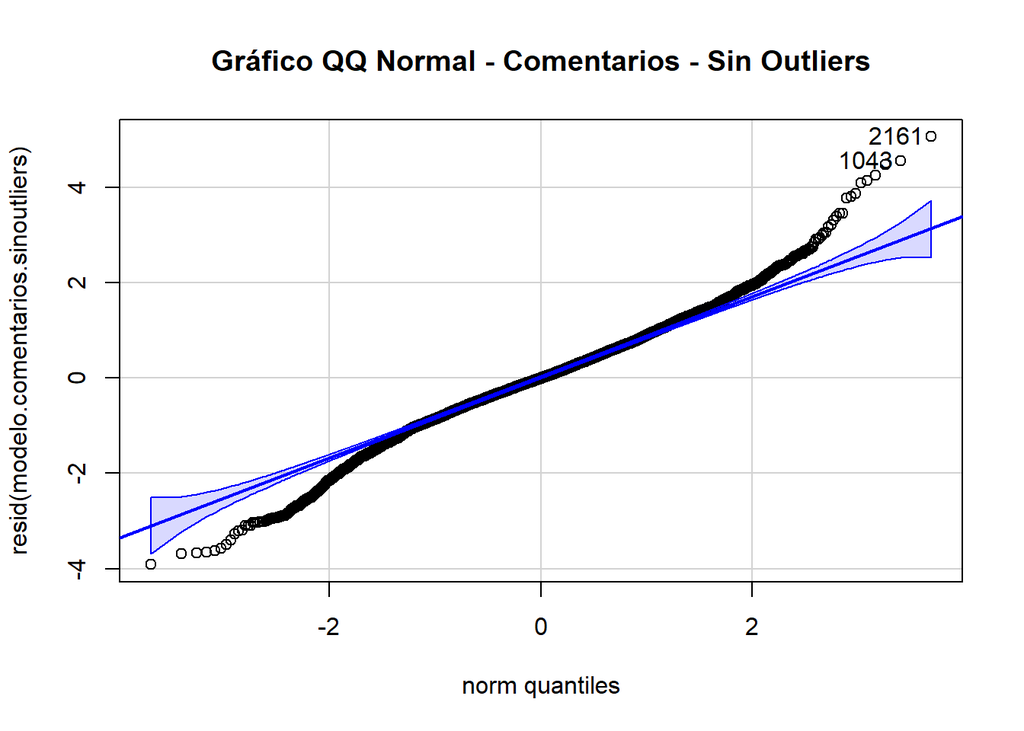

```
## 2161 1043
## 2078 1001
```

```r
#TABLA MODELSUMMARY
tabla4 <- modelsummary(
  modelo.comentarios.sinoutliers,
  estimate = "estimate",
  stars  = c('*' = 0.05, '**' = .01, '***' = .001),
  fmt = 3,
  shape = term ~ model + statistic,
  statistic = c('2.5%' = 'conf.low', '97.5%' = 'conf.high', 'p' = 'p.value'),
  conf_level = 0.95,
  output = "data.frame"
)

#RENOMBRADO COLUMNAS
colnames(tabla4)[2:6] <- c("Predictors","Estimates", "2.5%", "97.5%", "p")

N <- sum(tabla4[4]!="", na.rm = TRUE)
tabla4$CI <- paste0('[', tabla4$`2.5%`, ', ', tabla4$`97.5%`, ']')

tabla4$CI[(N+1):nrow(tabla4)] <- ''

tabla4$Predictors[2:N] <- c("Puntos ATP (Trf Raíz)", "Edad" , "Publicaciones (Trf Log)" , "Followers (Trf Log)" , "Following (Trf Log)" , "Nike" , "Wilson" , "Yonex" , "Adidas" , "Asics" , "Head" , "Australian Open" , "Roland Garros" , "Wimbledon" , "US Open" , "Fin de Semana" , "Video" , "Patrocinado" ,  "Tarde" , "Noche", "Nº Palabras (Trf Raíz)" , "Nº Hashtags" , "Nº Menciones" , "Nº Emojis"  , "Texto en Img" , "Instrumentos de Tenis" , "Nº Rostros (Trf Raíz)", "Felicidad", "Sorpresa", "Miedo", "Asco", "Enfado", "Tristeza", "Tono pos. (Trf Raíz)", "Tono neg. (Trf Raíz)", "Emoción pos. (Trf Raíz)", "Emoción neg. (Trf Raíz)", "Prosocial (Trf Raíz)", "Respetuoso (Trf Raíz)", "Estilo de vida (Trf Raíz)", "Salud (Trf Raíz)")

#SELECCIÓN COLUMNAS
tabla4 <- tabla4 %>% select('Predictors', 'Estimates', 'CI', 'p')
tabla4$Predictors[46] <- "R2 Marg./R2 Cond."
tabla4$Estimates[46] <- paste(tabla4$Estimates[46],tabla4$Estimates[47], sep = '/')
tabla4 <- tabla4[-c(47,48,49,51),]

#SEPARADO DE TABLA

tabla4.1 <- tabla4[1:34,]
tabla4.2 <- tabla4[35:nrow(tabla4),]
rownames(tabla4.2) <- NULL

tabla4_latex <- kable(tabla4, "latex", booktabs = TRUE, align = "lccc", caption = "Tabla del Modelo 4 sin outliers", row.names = FALSE) %>%
  kable_styling(
    latex_options = c("striped", "hold_position",  "scale_down"),
    full_width = FALSE,
    position = "center",
    font_size = 9
  ) %>%
  add_header_above(c(" " = 1, "Comentarios (Trf Log) sin outliers" = 3)) %>%
  pack_rows("Usuario", 2, 6, italic = TRUE, bold = FALSE) %>%
  pack_rows("Marcas", 7, 12, italic = TRUE, bold = FALSE) %>%
  pack_rows("Torneos", 13, 16, italic = TRUE, bold = FALSE) %>%
  pack_rows("Post", 17, 19, italic = TRUE, bold = FALSE) %>%
  pack_rows("Franja (ref = mañana)", 20, 21, italic = TRUE, bold = FALSE) %>%
  pack_rows("Texto", 22 , 25, italic = TRUE, bold = FALSE) %>%
  pack_rows("Imagen", 26 , 28, italic = TRUE, bold = FALSE) %>%
  pack_rows("Emoción Imagen (ref = neutral)", 29, 34, italic = TRUE, bold = FALSE) %>%
  pack_rows("Análisis Textual", 35 , 42, italic = TRUE, bold = FALSE) %>%
  row_spec(42, extra_latex_after = "\\midrule") %>%
  pack_rows("SD de Efectos Aleatorios", 43, 44, italic = TRUE, bold = FALSE) %>%
  row_spec(44, extra_latex_after = "\\midrule") %>%
  footnote(
    general = "* p<0.05; ** p<0.01; *** p<0.001",
    footnote_as_chunk = TRUE,
    escape = FALSE
  )%>%
  column_spec(2:7, width = "2cm")

# Gráfico QQ Normal
qqPlot(resid(modelo.comentarios.sinoutliers), main = 'Gráfico QQ Normal - Comentarios - Sin Outliers')
```

# Resultados finales

Mostramos los datos con outliers, porque son muy pocos.

```r
tab_model(modelo.likes, modelo.comentarios, title = 'Resultados Modelo 3 y Modelo 4 (Jugador + Post + Imágenes + LIWC)', dv.labels = c('Likes', 'Comentarios'))
```

Resultados Modelo 3 y Modelo 4 (Jugador + Post + Imágenes + LIWC)

|  | Likes |  |  | Comentarios |  |  |
| --- | --- | --- | --- | --- | --- | --- |
| Predictors | Estimates | CI | p | Estimates | CI | p |
| (Intercept) | 5.21 | 4.18 – 6.24 | **<0.001** | 1.23 | 0.10 – 2.36 | **0.033** |
| Puntos sqrt | 0.04 | 0.03 – 0.05 | **<0.001** | 0.03 | 0.02 – 0.04 | **<0.001** |
| Edad | -0.02 | -0.05 – 0.00 | 0.101 | -0.01 | -0.04 – 0.02 | 0.416 |
| publicaciones log | 0.36 | 0.23 – 0.49 | **<0.001** | 0.05 | -0.09 – 0.20 | 0.465 |
| followers log | -0.01 | -0.06 – 0.04 | 0.662 | 0.05 | 0.00 – 0.10 | **0.037** |
| following log | -0.08 | -0.21 – 0.05 | 0.236 | 0.14 | -0.00 – 0.28 | 0.056 |
| Nike | 1.25 | 0.57 – 1.94 | **<0.001** | 0.89 | 0.15 – 1.62 | **0.019** |
| Wilson | 0.31 | -0.31 – 0.93 | 0.330 | -0.02 | -0.69 – 0.65 | 0.947 |
| Yonex | 0.04 | -0.78 – 0.86 | 0.922 | 0.03 | -0.86 – 0.92 | 0.941 |
| Adidas | 0.75 | -0.23 – 1.73 | 0.132 | 0.67 | -0.40 – 1.74 | 0.220 |
| Asics | 0.67 | -0.14 – 1.49 | 0.106 | 0.88 | -0.00 – 1.75 | 0.050 |
| Head | 1.03 | 0.37 – 1.70 | **0.002** | 0.61 | -0.12 – 1.33 | 0.100 |
| Australian Open | 0.06 | -0.02 – 0.14 | 0.127 | 0.09 | -0.01 – 0.20 | 0.088 |
| Roland Garros | 0.03 | -0.05 – 0.11 | 0.512 | 0.05 | -0.06 – 0.16 | 0.365 |
| Wimbledon | 0.09 | 0.02 – 0.17 | **0.018** | 0.12 | 0.02 – 0.22 | **0.024** |
| US Open | 0.00 | -0.07 – 0.08 | 0.915 | 0.00 | -0.10 – 0.10 | 0.958 |
| weekend | 0.04 | -0.01 – 0.09 | 0.124 | 0.03 | -0.04 – 0.10 | 0.350 |
| video | -0.10 | -0.16 – -0.04 | **0.001** | -0.13 | -0.20 – -0.05 | **0.001** |
| is sponsored [True] | -0.32 | -0.66 – 0.02 | 0.069 | -0.31 | -0.76 – 0.14 | 0.175 |
| franja horaria [Tarde] | 0.03 | -0.03 – 0.09 | 0.377 | 0.03 | -0.05 – 0.11 | 0.498 |
| franja horaria [Noche] | 0.10 | 0.02 – 0.17 | **0.010** | 0.05 | -0.05 – 0.15 | 0.335 |
| word count sqrt | 0.01 | 0.00 – 0.03 | **0.050** | 0.05 | 0.03 – 0.06 | **<0.001** |
| num hashtags | -0.02 | -0.03 – -0.01 | **<0.001** | -0.03 | -0.04 – -0.02 | **<0.001** |
| num mentions | -0.02 | -0.04 – 0.00 | 0.101 | -0.01 | -0.04 – 0.01 | 0.368 |
| num emojis | 0.01 | -0.01 – 0.02 | 0.451 | 0.00 | -0.01 – 0.02 | 0.770 |
| texto detectado | 0.10 | 0.04 – 0.15 | **0.001** | 0.10 | 0.02 – 0.17 | **0.011** |
| tennis instruments | 0.19 | 0.14 – 0.24 | **<0.001** | 0.16 | 0.10 – 0.23 | **<0.001** |
| rostros sqrt | 0.05 | 0.03 – 0.08 | **<0.001** | 0.01 | -0.02 – 0.05 | 0.422 |
| emocion [happy] | 0.07 | -0.00 – 0.13 | 0.055 | 0.09 | 0.00 – 0.18 | **0.043** |
| emocion [surprise] | 0.08 | -0.14 – 0.31 | 0.479 | 0.01 | -0.28 – 0.31 | 0.933 |
| emocion [fear] | 0.03 | -0.06 – 0.11 | 0.531 | 0.03 | -0.08 – 0.14 | 0.568 |
| emocion [disgust] | -0.08 | -0.66 – 0.51 | 0.794 | -0.46 | -1.23 – 0.31 | 0.241 |
| emocion [angry] | 0.04 | -0.04 – 0.12 | 0.340 | 0.06 | -0.05 – 0.17 | 0.259 |
| emocion [sad] | 0.01 | -0.06 – 0.09 | 0.703 | 0.04 | -0.06 – 0.13 | 0.428 |
| tone pos sqrt | 0.02 | -0.00 – 0.03 | 0.095 | -0.00 | -0.02 – 0.02 | 1.000 |
| tone neg sqrt | 0.06 | 0.03 – 0.10 | **0.001** | 0.01 | -0.03 – 0.06 | 0.625 |
| emo pos sqrt | -0.03 | -0.06 – -0.01 | **0.005** | -0.01 | -0.04 – 0.02 | 0.452 |
| emo neg sqrt | 0.09 | 0.00 – 0.17 | **0.038** | 0.14 | 0.03 – 0.24 | **0.013** |
| prosocial sqrt | -0.05 | -0.07 – -0.02 | **0.001** | -0.04 | -0.08 – -0.01 | **0.022** |
| polite sqrt | 0.04 | 0.00 – 0.07 | **0.035** | 0.05 | 0.00 – 0.09 | **0.045** |
| Lifestyle sqrt | 0.02 | 0.01 – 0.03 | **0.006** | 0.00 | -0.02 – 0.02 | 0.838 |
| health sqrt | -0.05 | -0.09 – 0.00 | 0.050 | -0.04 | -0.10 – 0.02 | 0.199 |
| Random Effects |  |  |  |  |  |  |
| σ<sup>2</sup> | 0.59 |  |  | 1.02 |  |  |
| τ<sub>00</sub> | 0.86 <sub>username</sub> |  |  | 0.97 <sub>username</sub> |  |  |
| ICC | 0.59 |  |  | 0.49 |  |  |
| N | 341 <sub>username</sub> |  |  | 341 <sub>username</sub> |  |  |
| Observations | 4451 |  |  | 4451 |  |  |
| Marginal R<sup>2</sup> / Conditional R<sup>2</sup> | 0.601 / 0.838 |  |  | 0.352 / 0.668 |  |  |

```r
modelos <- list(
  "Likes" = modelo.likes,
  "Comentarios" = modelo.comentarios
)

tabla5 <- modelsummary(
  modelos,
  estimate = "estimate",
  stars  = c('*' = 0.05, '**' = .01, '***' = .001),
  fmt = 3,
  shape = term ~ model + statistic,
  statistic = c('2.5%' = 'conf.low', '97.5%' = 'conf.high', 'p' = 'p.value'),
  conf_level = 0.95,
  output = "data.frame"
)

# Renombrar columnas
colnames(tabla5)[2:10] <- c("Predictors","Estimates(1)", "2.5%(1)", "97.5%(1)", "p(1)","Estimates(2)", "2.5%(2)", "97.5%(2)", "p(2)")

N <- sum(tabla5[4]!="", na.rm = TRUE)
N <- sum(tabla5[8]!="", na.rm = TRUE)
tabla5$'CI(1)' <- paste0('[', tabla5$`2.5%(1)`, ', ', tabla5$`97.5%(1)`, ']')
tabla5$'CI(2)' <- paste0('[', tabla5$`2.5%(2)`, ', ', tabla5$`97.5%(2)`, ']')
tabla5$'CI(1)'[(N+1):nrow(tabla5)] <- ''
tabla5$'CI(2)'[(N+1):nrow(tabla5)] <- ''

tabla5$Predictors[2:N] <- c("Puntos ATP (Trf Raíz)", "Edad" , "Publicaciones (Trf Log)" , "Followers (Trf Log)" , "Following (Trf Log)" , "Nike" , "Wilson" , "Yonex" , "Adidas" , "Asics" , "Head" , "Australian Open" , "Roland Garros" , "Wimbledon" , "US Open" , "Fin de Semana" , "Video" , "Patrocinado" ,  "Tarde" , "Noche", "Nº Palabras (Trf Raíz)" , "Nº Hashtags" , "Nº Menciones" , "Nº Emojis"  , "Texto en Img" , "Instrumentos de Tenis" , "Nº Rostros (Trf Raíz)", "Felicidad", "Sorpresa", "Miedo", "Asco", "Enfado", "Tristeza", "Tono pos. (Trf Raíz)", "Tono neg. (Trf Raíz)", "Emoción pos. (Trf Raíz)", "Emoción neg. (Trf Raíz)", "Prosocial (Trf Raíz)", "Respetuoso (Trf Raíz)", "Estilo de vida (Trf Raíz)", "Salud (Trf Raíz)")

# Seleccionar columnas necesarias
tabla5 <- tabla5 %>% select("Predictors","Estimates(1)", "CI(1)", "p(1)","Estimates(2)", "CI(2)", "p(2)")
tabla5$Predictors[46] <- "R2 Marg./R2 Cond."
tabla5$Estimates[46] <- paste(tabla5$Estimates[46],tabla5$Estimates[47], sep = '/')
tabla5 <- tabla5[-c(47,48,49,51),]

#SEPARADO DE TABLA

tabla5.1 <- tabla5[1:34,]
tabla5.2 <- tabla5[35:nrow(tabla5),]
rownames(tabla5.2) <- NULL

tabla5_latex <- kable(tabla5, "latex", booktabs = TRUE, align = "lcccccc", col.names = c("Predictors", "Estimates", "CI", "p", "Estimates", "CI", "p"), caption = "Tabla de Resultados Modelo 3 y Modelo 4 (Jugador + Post + Imágenes + LIWC)", row.names = FALSE) %>%
  kable_styling(
    latex_options = c("striped", "hold_position"),
    full_width = FALSE,
    position = "center",
    font_size = 9
  ) %>%
  add_header_above(c(" " = 1, "Modelo 3: Likes (Trf Log)" = 3, "Modelo 4: Comentarios (Trf Log)" = 3)) %>%
  pack_rows("Usuario", 2, 6, italic = TRUE, bold = FALSE) %>%
  pack_rows("Marcas", 7, 12, italic = TRUE, bold = FALSE) %>%
  pack_rows("Torneos", 13, 16, italic = TRUE, bold = FALSE) %>%
  pack_rows("Post", 17, 19, italic = TRUE, bold = FALSE) %>%
  pack_rows("Franja (ref = mañana)", 20, 21, italic = TRUE, bold = FALSE) %>%
  pack_rows("Texto", 22 , 25, italic = TRUE, bold = FALSE) %>%
  pack_rows("Imagen", 26 , 28, italic = TRUE, bold = FALSE) %>%
  pack_rows("Emoción Imagen (ref = neutral)", 29, 34, italic = TRUE, bold = FALSE) %>%
  pack_rows("Análisis Textual", 35 , 42, italic = TRUE, bold = FALSE) %>%
  row_spec(42, extra_latex_after = "\\midrule") %>%
  pack_rows("SD de Efectos Aleatorios", 43, 44, italic = TRUE, bold = FALSE) %>%
  row_spec(44, extra_latex_after = "\\midrule") %>%
  footnote(
    general = "* p<0.05; ** p<0.01; *** p<0.001",
    footnote_as_chunk = TRUE,
    escape = FALSE
  )%>%
  column_spec(2:7, width = "2cm")
```

# Comparación de likes sin y con LIWC

```r
likes_sin_imagen_sin_LIWC <- likes.log ~ Puntos.sqrt + Edad + publicaciones.log + followers.log + following.log + Nike + Wilson + Yonex + Adidas + Asics + Head + Australian_Open + Roland_Garros + Wimbledon + US_Open + weekend + video + is_sponsored +  franja_horaria +  word_count.sqrt + num_hashtags + num_mentions + num_emojis + (1|username)

likes_con_imagen_sin_LIWC <- likes.log ~ Puntos.sqrt + Edad + publicaciones.log + followers.log + following.log + Nike + Wilson + Yonex + Adidas + Asics + Head + Australian_Open + Roland_Garros + Wimbledon + US_Open + weekend + video + is_sponsored +  franja_horaria +  word_count.sqrt + num_hashtags + num_mentions + num_emojis  + texto.detectado + tennis.instruments + rostros.sqrt + emocion + (1|username)

modelo.likes_sin_imagen_sin_LIWC <- lmer(likes_sin_imagen_sin_LIWC, data=datos, REML=FALSE)

modelo.likes_con_imagen_sin_LIWC <- lmer(likes_con_imagen_sin_LIWC, data=datos, REML=FALSE)


tab_model(modelo.likes_sin_imagen_sin_LIWC ,modelo.likes_con_imagen_sin_LIWC, modelo.likes, title = 'Resultados de Comparación de modelos para likes', dv.labels = c('Sin Imagen', 'Con Imagen', 'Con Imagen + Texto'))
```

Resultados de Comparación de modelos para likes

|  | Sin Imagen |  |  | Con Imagen |  |  | Con Imagen + Texto |  |  |
| --- | --- | --- | --- | --- | --- | --- | --- | --- | --- |
| Predictors | Estimates | CI | p | Estimates | CI | p | Estimates | CI | p |
| (Intercept) | 5.52 | 4.49 – 6.55 | **<0.001** | 5.23 | 4.20 – 6.26 | **<0.001** | 5.21 | 4.18 – 6.24 | **<0.001** |
| Puntos sqrt | 0.04 | 0.03 – 0.05 | **<0.001** | 0.04 | 0.03 – 0.05 | **<0.001** | 0.04 | 0.03 – 0.05 | **<0.001** |
| Edad | -0.02 | -0.05 – 0.00 | 0.069 | -0.02 | -0.05 – 0.00 | 0.089 | -0.02 | -0.05 – 0.00 | 0.101 |
| publicaciones log | 0.36 | 0.23 – 0.49 | **<0.001** | 0.36 | 0.23 – 0.50 | **<0.001** | 0.36 | 0.23 – 0.49 | **<0.001** |
| followers log | -0.01 | -0.06 – 0.03 | 0.580 | -0.01 | -0.06 – 0.04 | 0.654 | -0.01 | -0.06 – 0.04 | 0.662 |
| following log | -0.08 | -0.21 – 0.05 | 0.248 | -0.08 | -0.21 – 0.05 | 0.243 | -0.08 | -0.21 – 0.05 | 0.236 |
| Nike | 1.21 | 0.53 – 1.90 | **0.001** | 1.24 | 0.56 – 1.93 | **<0.001** | 1.25 | 0.57 – 1.94 | **<0.001** |
| Wilson | 0.34 | -0.28 – 0.96 | 0.285 | 0.31 | -0.31 – 0.94 | 0.322 | 0.31 | -0.31 – 0.93 | 0.330 |
| Yonex | 0.01 | -0.81 – 0.84 | 0.973 | 0.02 | -0.80 – 0.84 | 0.964 | 0.04 | -0.78 – 0.86 | 0.922 |
| Adidas | 0.72 | -0.26 – 1.70 | 0.152 | 0.74 | -0.24 – 1.72 | 0.140 | 0.75 | -0.23 – 1.73 | 0.132 |
| Asics | 0.64 | -0.18 – 1.46 | 0.126 | 0.67 | -0.15 – 1.48 | 0.111 | 0.67 | -0.14 – 1.49 | 0.106 |
| Head | 1.07 | 0.40 – 1.73 | **0.002** | 1.05 | 0.39 – 1.72 | **0.002** | 1.03 | 0.37 – 1.70 | **0.002** |
| Australian Open | 0.06 | -0.02 – 0.14 | 0.135 | 0.06 | -0.02 – 0.14 | 0.168 | 0.06 | -0.02 – 0.14 | 0.127 |
| Roland Garros | 0.02 | -0.06 – 0.10 | 0.660 | 0.02 | -0.06 – 0.11 | 0.563 | 0.03 | -0.05 – 0.11 | 0.512 |
| Wimbledon | 0.10 | 0.02 – 0.17 | **0.017** | 0.09 | 0.02 – 0.17 | **0.018** | 0.09 | 0.02 – 0.17 | **0.018** |
| US Open | 0.02 | -0.06 – 0.10 | 0.661 | 0.00 | -0.08 – 0.08 | 0.990 | 0.00 | -0.07 – 0.08 | 0.915 |
| weekend | 0.04 | -0.02 – 0.09 | 0.188 | 0.04 | -0.02 – 0.09 | 0.169 | 0.04 | -0.01 – 0.09 | 0.124 |
| video | -0.12 | -0.17 – -0.06 | **<0.001** | -0.09 | -0.15 – -0.03 | **0.002** | -0.10 | -0.16 – -0.04 | **0.001** |
| is sponsored [True] | -0.35 | -0.70 – -0.01 | **0.046** | -0.33 | -0.68 – 0.01 | 0.058 | -0.32 | -0.66 – 0.02 | 0.069 |
| franja horaria [Tarde] | 0.03 | -0.03 – 0.10 | 0.343 | 0.03 | -0.03 – 0.09 | 0.337 | 0.03 | -0.03 – 0.09 | 0.377 |
| franja horaria [Noche] | 0.11 | 0.04 – 0.19 | **0.004** | 0.11 | 0.03 – 0.18 | **0.006** | 0.10 | 0.02 – 0.17 | **0.010** |
| word count sqrt | 0.01 | 0.00 – 0.03 | **0.033** | 0.02 | 0.00 – 0.03 | **0.016** | 0.01 | 0.00 – 0.03 | **0.050** |
| num hashtags | -0.02 | -0.03 – -0.01 | **0.001** | -0.02 | -0.03 – -0.01 | **<0.001** | -0.02 | -0.03 – -0.01 | **<0.001** |
| num mentions | -0.01 | -0.03 – 0.01 | 0.473 | -0.02 | -0.04 – 0.00 | 0.101 | -0.02 | -0.04 – 0.00 | 0.101 |
| num emojis | 0.00 | -0.01 – 0.02 | 0.467 | 0.00 | -0.01 – 0.02 | 0.644 | 0.01 | -0.01 – 0.02 | 0.451 |
| texto detectado |  |  |  | 0.10 | 0.04 – 0.16 | **<0.001** | 0.10 | 0.04 – 0.15 | **0.001** |
| tennis instruments |  |  |  | 0.20 | 0.15 – 0.25 | **<0.001** | 0.19 | 0.14 – 0.24 | **<0.001** |
| rostros sqrt |  |  |  | 0.05 | 0.02 – 0.07 | **<0.001** | 0.05 | 0.03 – 0.08 | **<0.001** |
| emocion [happy] |  |  |  | 0.06 | -0.00 – 0.13 | 0.066 | 0.07 | -0.00 – 0.13 | 0.055 |
| emocion [surprise] |  |  |  | 0.08 | -0.15 – 0.31 | 0.492 | 0.08 | -0.14 – 0.31 | 0.479 |
| emocion [fear] |  |  |  | 0.03 | -0.06 – 0.11 | 0.517 | 0.03 | -0.06 – 0.11 | 0.531 |
| emocion [disgust] |  |  |  | -0.09 | -0.68 – 0.50 | 0.763 | -0.08 | -0.66 – 0.51 | 0.794 |
| emocion [angry] |  |  |  | 0.04 | -0.04 – 0.13 | 0.325 | 0.04 | -0.04 – 0.12 | 0.340 |
| emocion [sad] |  |  |  | 0.01 | -0.06 – 0.08 | 0.761 | 0.01 | -0.06 – 0.09 | 0.703 |
| tone pos sqrt |  |  |  |  |  |  | 0.02 | -0.00 – 0.03 | 0.095 |
| tone neg sqrt |  |  |  |  |  |  | 0.06 | 0.03 – 0.10 | **0.001** |
| emo pos sqrt |  |  |  |  |  |  | -0.03 | -0.06 – -0.01 | **0.005** |
| emo neg sqrt |  |  |  |  |  |  | 0.09 | 0.00 – 0.17 | **0.038** |
| prosocial sqrt |  |  |  |  |  |  | -0.05 | -0.07 – -0.02 | **0.001** |
| polite sqrt |  |  |  |  |  |  | 0.04 | 0.00 – 0.07 | **0.035** |
| Lifestyle sqrt |  |  |  |  |  |  | 0.02 | 0.01 – 0.03 | **0.006** |
| health sqrt |  |  |  |  |  |  | -0.05 | -0.09 – 0.00 | 0.050 |
| Random Effects |  |  |  |  |  |  |  |  |  |
| σ<sup>2</sup> | 0.61 |  |  | 0.59 |  |  | 0.59 |  |  |
| τ<sub>00</sub> | 0.86 <sub>username</sub> |  |  | 0.86 <sub>username</sub> |  |  | 0.86 <sub>username</sub> |  |  |
| ICC | 0.59 |  |  | 0.59 |  |  | 0.59 |  |  |
| N | 341 <sub>username</sub> |  |  | 341 <sub>username</sub> |  |  | 341 <sub>username</sub> |  |  |
| Observations | 4451 |  |  | 4451 |  |  | 4451 |  |  |
| Marginal R<sup>2</sup> / Conditional R<sup>2</sup> | 0.594 / 0.832 |  |  | 0.598 / 0.836 |  |  | 0.601 / 0.838 |  |  |

```r
tab_df(anova(modelo.likes_con_imagen_sin_LIWC, modelo.likes), title = 'ANOVA entre ambos modelos', show.rownames =T)
```

ANOVA entre ambos modelos

| Row | npar | AIC | BIC | logLik | deviance | Chisq | Df | Pr..Chisq. |
| --- | --- | --- | --- | --- | --- | --- | --- | --- |
| modelo.likes_con_imagen_sin_LIWC | 36 | 11200.34 | 11430.77 | -5564.17 | 11128.34 | NA | NA | NA |
| modelo.likes | 44 | 11161.35 | 11442.99 | -5536.68 | 11073.35 | 54.99 | 8 | 0.00 |

```r
modelos1 <- list(
  "Likes sin Imagen" = modelo.likes_sin_imagen_sin_LIWC,
  "Likes con Imagen" = modelo.likes_con_imagen_sin_LIWC,
  "Likes con Imagen + Análisis Textual" = modelo.likes
)

tabla6 <- modelsummary(
  modelos1,
  estimate = "estimate",
  stars  = c('*' = 0.05, '**' = .01, '***' = .001),
  fmt = 3,
  shape = term ~ model + statistic,
  statistic = c('2.5%' = 'conf.low', '97.5%' = 'conf.high', 'p' = 'p.value'),
  conf_level = 0.95,
  output = "data.frame"
)

# Extraer las filas 26 y 27
fila_26_27 <- tabla6[26:27, ]

# Eliminar las filas 26 y 27 del data.frame
tabla6 <- tabla6[-c(26, 27), ]

# Reiniciar los nombres de las filas
rownames(tabla6) <- 1:nrow(tabla6)

# Insertar las filas 26 y 27 entre las filas 43 y 44
tabla6 <- rbind(tabla6[1:42, ], fila_26_27, tabla6[43:nrow(tabla6), ])

# Reiniciar los nombres de las filas nuevamente
rownames(tabla6) <- 1:nrow(tabla6)

fila_indices <- 45:51
ultima_columna <- ncol(tabla6)
tabla6[fila_indices, 11] <- tabla6[fila_indices, ultima_columna]
tabla6[fila_indices, ultima_columna] <- ""

# Renombrar columnas
colnames(tabla6)[2:14] <- c("Predictors","Estimates(1)", "2.5%(1)", "97.5%(1)", "p(1)","Estimates(2)", "2.5%(2)", "97.5%(2)", "p(2)","Estimates(3)", "2.5%(3)", "97.5%(3)", "p(3)")

N1 <- sum(tabla6[4]!="", na.rm = TRUE)
N2 <- sum(tabla6[8]!="", na.rm = TRUE)
N3 <- sum(tabla6[12]!="", na.rm = TRUE)
tabla6$'CI(1)' <- paste0('[', tabla6$`2.5%(1)`, ', ', tabla6$`97.5%(1)`, ']')
tabla6$'CI(2)' <- paste0('[', tabla6$`2.5%(2)`, ', ', tabla6$`97.5%(2)`, ']')
tabla6$'CI(3)' <- paste0('[', tabla6$`2.5%(3)`, ', ', tabla6$`97.5%(3)`, ']')
tabla6$'CI(1)'[(N1+1):nrow(tabla6)] <- ''
tabla6$'CI(2)'[(N2+1):nrow(tabla6)] <- ''
tabla6$'CI(3)'[(N3+1):nrow(tabla6)] <- ''

tabla6$Predictors[2:N3] <- c("Puntos ATP (Trf Raíz)", "Edad" , "Publicaciones (Trf Log)" , "Followers (Trf Log)" , "Following (Trf Log)" , "Nike" , "Wilson" , "Yonex" , "Adidas" , "Asics" , "Head" , "Australian Open" , "Roland Garros" , "Wimbledon" , "US Open" , "Fin de Semana" , "Video" , "Patrocinado" ,  "Tarde" , "Noche", "Nº Palabras (Trf Raíz)" , "Nº Hashtags" , "Nº Menciones" , "Nº Emojis"  , "Texto en Img" , "Instrumentos de Tenis" , "Nº Rostros (Trf Raíz)", "Felicidad", "Sorpresa", "Miedo", "Asco", "Enfado", "Tristeza", "Tono pos. (Trf Raíz)", "Tono neg. (Trf Raíz)", "Emoción pos. (Trf Raíz)", "Emoción neg. (Trf Raíz)", "Prosocial (Trf Raíz)", "Respetuoso (Trf Raíz)", "Estilo de vida (Trf Raíz)", "Salud (Trf Raíz)")


tabla6 <- tabla6 %>% select("Predictors","Estimates(1)", "p(1)", "Estimates(2)", "p(2)", "Estimates(3)", "p(3)")
tabla6$Predictors[46] <- "R2 Marg./R2 Cond."
tabla6$'Estimates(1)'[46] <- paste(tabla6$'Estimates(1)'[46],tabla6$'Estimates(1)'[47], sep = '/')
tabla6$'Estimates(2)'[46] <- paste(tabla6$'Estimates(2)'[46],tabla6$'Estimates(2)'[47], sep = '/')
tabla6$'Estimates(3)'[46] <- paste(tabla6$'Estimates(3)'[46],tabla6$'Estimates(3)'[47], sep = '/')
tabla6 <- tabla6[-c(47,48,49,51),]

tabla6.1 <- tabla6[1:34,]
tabla6.2 <- tabla6[35:nrow(tabla6),]
rownames(tabla6.2) <- NULL

tabla6_latex <- kable(tabla6, "latex", booktabs = TRUE, align = "lcccccc", col.names = c("Predictors", "Estimates", "p", "Estimates", "p", "Estimates", "p"), caption = "Comparación de likes", row.names = FALSE) %>%
  kable_styling(
    latex_options = c("striped", "hold_position", "scale_down"),
    full_width = FALSE,
    position = "center"
  ) %>%
  add_header_above(c(" " = 1, "Likes (Trf Log)" = 2, "Likes (Trf Log) + img" = 2, "Likes (Trf Log) con img + texto" = 2)) %>%
  pack_rows("Usuario", 2, 6, italic = TRUE, bold = FALSE) %>%
  pack_rows("Marcas", 7, 12, italic = TRUE, bold = FALSE) %>%
  pack_rows("Torneos", 13, 16, italic = TRUE, bold = FALSE) %>%
  pack_rows("Post", 17, 19, italic = TRUE, bold = FALSE) %>%
  pack_rows("Franja (ref = mañana)", 20, 21, italic = TRUE, bold = FALSE) %>%
  pack_rows("Texto", 22 , 25, italic = TRUE, bold = FALSE) %>%
  pack_rows("Imagen", 26 , 28, italic = TRUE, bold = FALSE) %>%
  pack_rows("Emoción Imagen (ref = neutral)", 29, 34, italic = TRUE, bold = FALSE) %>%
  pack_rows("Análisis Textual", 35 , 42, italic = TRUE, bold = FALSE) %>%
  row_spec(42, extra_latex_after = "\\midrule") %>%
  pack_rows("SD de Efectos Aleatorios", 43, 44, italic = TRUE, bold = FALSE) %>%
  row_spec(44, extra_latex_after = "\\midrule") %>%
  footnote(
    general = "* p<0.05; ** p<0.01; *** p<0.001",
    footnote_as_chunk = TRUE,
    escape = FALSE
  )

tabla6.1_latex <- kable(tabla6.1, "latex", booktabs = TRUE, align = "lcccccc", col.names = c("Predictors", "Estimates", "p", "Estimates", "p", "Estimates", "p"), caption = "Comparación de likes", row.names = FALSE) %>%
  kable_styling(
    latex_options = c("striped", "hold_position", "scale_down"),
    full_width = FALSE,
    position = "center"
  ) %>%
  add_header_above(c(" " = 1, "Likes (Trf Log) sin imagen" = 2, "Likes (Trf Log) con imagen" = 2, "Likes (Trf Log) con imagen + texto" = 2)) %>%
  pack_rows("Usuario", 2, 6, italic = TRUE, bold = FALSE) %>%
  pack_rows("Marcas", 7, 12, italic = TRUE, bold = FALSE) %>%
  pack_rows("Torneos", 13, 16, italic = TRUE, bold = FALSE) %>%
  pack_rows("Post", 17, 19, italic = TRUE, bold = FALSE) %>%
  pack_rows("Franja (ref = mañana)", 20, 21, italic = TRUE, bold = FALSE) %>%
  pack_rows("Texto", 22 , 25, italic = TRUE, bold = FALSE) %>%
  pack_rows("Imagen", 26 , 28, italic = TRUE, bold = FALSE) %>%
  pack_rows("Emoción Imagen (ref = neutral)", 29, 34, italic = TRUE, bold = FALSE) %>%
  footnote(
    general = "* p<0.05; ** p<0.01; *** p<0.001",
    footnote_as_chunk = TRUE,
    escape = FALSE
  )


tabla6.2_latex <- kable(tabla6.2, "latex", booktabs = TRUE, align = "lcccccc", col.names = c("Predictors", "Estimates", "p", "Estimates", "p", "Estimates", "p"), caption = "Comparación de likes", row.names = FALSE) %>%
  kable_styling(
    latex_options = c("striped", "hold_position", "scale_down"),
    full_width = FALSE,
    position = "center"
  ) %>%
  add_header_above(c(" " = 1, "Likes (Trf Log)" = 2, "Likes (Trf Log) + img" = 2, "Likes (Trf Log) con img + texto" = 2)) %>%
  pack_rows("Análisis Textual", 1 , 8, italic = TRUE, bold = FALSE) %>%
  row_spec(8, extra_latex_after = "\\midrule") %>%
  pack_rows("SD de Efectos Aleatorios", 9, 10, italic = TRUE, bold = FALSE) %>%
  row_spec(10, extra_latex_after = "\\midrule") %>%
  footnote(
    general = "* p<0.05; ** p<0.01; *** p<0.001",
    footnote_as_chunk = TRUE,
    escape = FALSE
  )

#ANOVA 1
tab_df(anova(modelo.likes_sin_imagen_sin_LIWC, modelo.likes_con_imagen_sin_LIWC), title = 'ANOVA entre ambos modelos', show.rownames =T)
```

ANOVA entre ambos modelos

| Row | npar | AIC | BIC | logLik | deviance | Chisq | Df | Pr..Chisq. |
| --- | --- | --- | --- | --- | --- | --- | --- | --- |
| modelo.likes_sin_imagen_sin_LIWC | 27 | 11278.50 | 11451.32 | -5612.25 | 11224.50 | NA | NA | NA |
| modelo.likes_con_imagen_sin_LIWC | 36 | 11200.34 | 11430.77 | -5564.17 | 11128.34 | 96.16 | 9 | 0.00 |

```r
options(knitr.kable.NA="")

anova_result <- anova(modelo.likes_sin_imagen_sin_LIWC, modelo.likes_con_imagen_sin_LIWC)

anova_df <- as.data.frame(anova_result)

colnames(anova_df) <- c("Npar", "AIC", "BIG", "logLik","Deviance", "Chisq", "Df", "Pr.Chisq.")

anova_latex <- kable(anova_df, format = "latex", booktabs = TRUE, caption = "ANOVA entre Likes sin Img y Likes con Img") %>%
   kable_styling(latex_options = c("striped", "hold_position"), full_width = FALSE, position = "center")

#ANOVA 2
tab_df(anova(modelo.likes_con_imagen_sin_LIWC, modelo.likes), title = 'ANOVA entre ambos modelos', show.rownames =T)
```

ANOVA entre ambos modelos

| Row | npar | AIC | BIC | logLik | deviance | Chisq | Df | Pr..Chisq. |
| --- | --- | --- | --- | --- | --- | --- | --- | --- |
| modelo.likes_con_imagen_sin_LIWC | 36 | 11200.34 | 11430.77 | -5564.17 | 11128.34 | NA | NA | NA |
| modelo.likes | 44 | 11161.35 | 11442.99 | -5536.68 | 11073.35 | 54.99 | 8 | 0.00 |

```r
options(knitr.kable.NA="")

anova_result2 <- anova(modelo.likes_con_imagen_sin_LIWC, modelo.likes)

anova_df2 <- as.data.frame(anova_result2)

colnames(anova_df2) <- c("Npar", "AIC", "BIG", "logLik","Deviance", "Chisq", "Df", "Pr.Chisq.")

anova_latex2 <- kable(anova_df2, format = "latex", booktabs = TRUE, caption = "ANOVA entre Likes con Img y Likes con Img + Texto") %>%
   kable_styling(latex_options = c("striped", "hold_position"), full_width = FALSE, position = "center")
```

# Comparación de comentarios

```r
comentarios_sin_imagen_sin_LIWC <- comentarios.log ~ Puntos.sqrt + Edad + publicaciones.log + followers.log + following.log + Nike + Wilson + Yonex + Adidas + Asics + Head + Australian_Open + Roland_Garros + Wimbledon + US_Open + weekend + video + is_sponsored +  franja_horaria +  word_count.sqrt + num_hashtags + num_mentions + num_emojis + (1|username)

comentarios_con_imagen_sin_LIWC <- comentarios.log ~ Puntos.sqrt + Edad + publicaciones.log + followers.log + following.log + Nike + Wilson + Yonex + Adidas + Asics + Head + Australian_Open + Roland_Garros + Wimbledon + US_Open + weekend + video + is_sponsored +  franja_horaria +  word_count.sqrt + num_hashtags + num_mentions + num_emojis  + texto.detectado + tennis.instruments + rostros.sqrt + emocion + (1|username)

modelo.comentarios_sin_imagen_sin_LIWC <- lmer(comentarios_sin_imagen_sin_LIWC, data=datos, REML=FALSE)

modelo.comentarios_con_imagen_sin_LIWC <- lmer(comentarios_con_imagen_sin_LIWC, data=datos, REML=FALSE)


tab_model(modelo.comentarios_sin_imagen_sin_LIWC ,modelo.comentarios_con_imagen_sin_LIWC, modelo.comentarios, title = 'Resultados de Comparación de modelos para comentarios', dv.labels = c('Sin Imagen', 'Con Imagen', 'Con Imagen + Texto'))
```

Resultados de Comparación de modelos para comentarios

|  | Sin Imagen |  |  | Con Imagen |  |  | Con Imagen + Texto |  |  |
| --- | --- | --- | --- | --- | --- | --- | --- | --- | --- |
| Predictors | Estimates | CI | p | Estimates | CI | p | Estimates | CI | p |
| (Intercept) | 1.43 | 0.30 – 2.56 | **0.013** | 1.22 | 0.09 – 2.35 | **0.035** | 1.23 | 0.10 – 2.36 | **0.033** |
| Puntos sqrt | 0.03 | 0.02 – 0.04 | **<0.001** | 0.03 | 0.02 – 0.04 | **<0.001** | 0.03 | 0.02 – 0.04 | **<0.001** |
| Edad | -0.01 | -0.04 – 0.02 | 0.346 | -0.01 | -0.04 – 0.02 | 0.393 | -0.01 | -0.04 – 0.02 | 0.416 |
| publicaciones log | 0.05 | -0.09 – 0.20 | 0.464 | 0.06 | -0.09 – 0.20 | 0.442 | 0.05 | -0.09 – 0.20 | 0.465 |
| followers log | 0.05 | 0.00 – 0.10 | **0.043** | 0.05 | 0.00 – 0.10 | **0.036** | 0.05 | 0.00 – 0.10 | **0.037** |
| following log | 0.14 | -0.00 – 0.28 | 0.052 | 0.14 | -0.00 – 0.28 | 0.054 | 0.14 | -0.00 – 0.28 | 0.056 |
| Nike | 0.85 | 0.11 – 1.59 | **0.024** | 0.88 | 0.14 – 1.62 | **0.019** | 0.89 | 0.15 – 1.62 | **0.019** |
| Wilson | 0.01 | -0.67 – 0.68 | 0.987 | -0.01 | -0.68 – 0.66 | 0.972 | -0.02 | -0.69 – 0.65 | 0.947 |
| Yonex | 0.02 | -0.87 – 0.91 | 0.966 | 0.02 | -0.87 – 0.91 | 0.960 | 0.03 | -0.86 – 0.92 | 0.941 |
| Adidas | 0.64 | -0.43 – 1.71 | 0.243 | 0.66 | -0.41 – 1.73 | 0.228 | 0.67 | -0.40 – 1.74 | 0.220 |
| Asics | 0.84 | -0.03 – 1.72 | 0.060 | 0.87 | -0.01 – 1.75 | 0.052 | 0.88 | -0.00 – 1.75 | 0.050 |
| Head | 0.62 | -0.10 – 1.35 | 0.091 | 0.61 | -0.11 – 1.34 | 0.095 | 0.61 | -0.12 – 1.33 | 0.100 |
| Australian Open | 0.09 | -0.02 – 0.19 | 0.108 | 0.09 | -0.02 – 0.19 | 0.104 | 0.09 | -0.01 – 0.20 | 0.088 |
| Roland Garros | 0.05 | -0.06 – 0.15 | 0.413 | 0.05 | -0.06 – 0.16 | 0.370 | 0.05 | -0.06 – 0.16 | 0.365 |
| Wimbledon | 0.12 | 0.02 – 0.22 | **0.022** | 0.12 | 0.02 – 0.22 | **0.021** | 0.12 | 0.02 – 0.22 | **0.024** |
| US Open | 0.02 | -0.09 – 0.12 | 0.770 | 0.00 | -0.10 – 0.10 | 0.985 | 0.00 | -0.10 – 0.10 | 0.958 |
| weekend | 0.03 | -0.04 – 0.10 | 0.431 | 0.03 | -0.04 – 0.10 | 0.413 | 0.03 | -0.04 – 0.10 | 0.350 |
| video | -0.14 | -0.22 – -0.07 | **<0.001** | -0.13 | -0.20 – -0.05 | **0.001** | -0.13 | -0.20 – -0.05 | **0.001** |
| is sponsored [True] | -0.32 | -0.77 – 0.13 | 0.166 | -0.31 | -0.76 – 0.13 | 0.169 | -0.31 | -0.76 – 0.14 | 0.175 |
| franja horaria [Tarde] | 0.03 | -0.06 – 0.11 | 0.555 | 0.03 | -0.06 – 0.11 | 0.533 | 0.03 | -0.05 – 0.11 | 0.498 |
| franja horaria [Noche] | 0.05 | -0.05 – 0.15 | 0.317 | 0.05 | -0.05 – 0.15 | 0.337 | 0.05 | -0.05 – 0.15 | 0.335 |
| word count sqrt | 0.05 | 0.03 – 0.06 | **<0.001** | 0.05 | 0.03 – 0.06 | **<0.001** | 0.05 | 0.03 – 0.06 | **<0.001** |
| num hashtags | -0.03 | -0.04 – -0.02 | **<0.001** | -0.03 | -0.04 – -0.02 | **<0.001** | -0.03 | -0.04 – -0.02 | **<0.001** |
| num mentions | -0.00 | -0.03 – 0.02 | 0.772 | -0.01 | -0.04 – 0.01 | 0.403 | -0.01 | -0.04 – 0.01 | 0.368 |
| num emojis | 0.00 | -0.01 – 0.02 | 0.773 | 0.00 | -0.02 – 0.02 | 0.888 | 0.00 | -0.01 – 0.02 | 0.770 |
| texto detectado |  |  |  | 0.10 | 0.02 – 0.17 | **0.011** | 0.10 | 0.02 – 0.17 | **0.011** |
| tennis instruments |  |  |  | 0.17 | 0.10 – 0.23 | **<0.001** | 0.16 | 0.10 – 0.23 | **<0.001** |
| rostros sqrt |  |  |  | 0.01 | -0.02 – 0.04 | 0.546 | 0.01 | -0.02 – 0.05 | 0.422 |
| emocion [happy] |  |  |  | 0.09 | 0.00 – 0.18 | **0.046** | 0.09 | 0.00 – 0.18 | **0.043** |
| emocion [surprise] |  |  |  | 0.01 | -0.28 – 0.31 | 0.924 | 0.01 | -0.28 – 0.31 | 0.933 |
| emocion [fear] |  |  |  | 0.03 | -0.08 – 0.14 | 0.566 | 0.03 | -0.08 – 0.14 | 0.568 |
| emocion [disgust] |  |  |  | -0.46 | -1.23 – 0.31 | 0.238 | -0.46 | -1.23 – 0.31 | 0.241 |
| emocion [angry] |  |  |  | 0.06 | -0.05 – 0.17 | 0.264 | 0.06 | -0.05 – 0.17 | 0.259 |
| emocion [sad] |  |  |  | 0.04 | -0.06 – 0.13 | 0.437 | 0.04 | -0.06 – 0.13 | 0.428 |
| tone pos sqrt |  |  |  |  |  |  | -0.00 | -0.02 – 0.02 | 1.000 |
| tone neg sqrt |  |  |  |  |  |  | 0.01 | -0.03 – 0.06 | 0.625 |
| emo pos sqrt |  |  |  |  |  |  | -0.01 | -0.04 – 0.02 | 0.452 |
| emo neg sqrt |  |  |  |  |  |  | 0.14 | 0.03 – 0.24 | **0.013** |
| prosocial sqrt |  |  |  |  |  |  | -0.04 | -0.08 – -0.01 | **0.022** |
| polite sqrt |  |  |  |  |  |  | 0.05 | 0.00 – 0.09 | **0.045** |
| Lifestyle sqrt |  |  |  |  |  |  | 0.00 | -0.02 – 0.02 | 0.838 |
| health sqrt |  |  |  |  |  |  | -0.04 | -0.10 – 0.02 | 0.199 |
| Random Effects |  |  |  |  |  |  |  |  |  |
| σ<sup>2</sup> | 1.03 |  |  | 1.02 |  |  | 1.02 |  |  |
| τ<sub>00</sub> | 0.97 <sub>username</sub> |  |  | 0.97 <sub>username</sub> |  |  | 0.97 <sub>username</sub> |  |  |
| ICC | 0.49 |  |  | 0.49 |  |  | 0.49 |  |  |
| N | 341 <sub>username</sub> |  |  | 341 <sub>username</sub> |  |  | 341 <sub>username</sub> |  |  |
| Observations | 4451 |  |  | 4451 |  |  | 4451 |  |  |
| Marginal R<sup>2</sup> / Conditional R<sup>2</sup> | 0.348 / 0.665 |  |  | 0.351 / 0.667 |  |  | 0.352 / 0.668 |  |  |

```r
tab_df(anova(modelo.comentarios_con_imagen_sin_LIWC, modelo.comentarios), title = 'ANOVA entre ambos modelos', show.rownames =T)
```

ANOVA entre ambos modelos

| Row | npar | AIC | BIC | logLik | deviance | Chisq | Df | Pr..Chisq. |
| --- | --- | --- | --- | --- | --- | --- | --- | --- |
| modelo.comentarios_con_imagen_sin_LIWC | 36 | 13485.47 | 13715.90 | -6706.73 | 13413.47 | NA | NA | NA |
| modelo.comentarios | 44 | 13485.12 | 13766.76 | -6698.56 | 13397.12 | 16.35 | 8 | 0.04 |

```r
modelos1 <- list(
  "Comentarios sin Imagen" = modelo.comentarios_sin_imagen_sin_LIWC,
  "Comentarios con Imagen" = modelo.comentarios_con_imagen_sin_LIWC,
  "Comentarios con Imagen + Análisis Textual" = modelo.comentarios
)

tabla7 <- modelsummary(
  modelos1,
  estimate = "estimate",
  stars  = c('*' = 0.05, '**' = .01, '***' = .001),
  fmt = 3,
  shape = term ~ model + statistic,
  statistic = c('2.5%' = 'conf.low', '97.5%' = 'conf.high', 'p' = 'p.value'),
  conf_level = 0.95,
  output = "data.frame"
)

# Extraer las filas 26 y 27
fila_26_27 <- tabla7[26:27, ]

# Eliminar las filas 26 y 27 del data.frame
tabla7 <- tabla7[-c(26, 27), ]

# Reiniciar los nombres de las filas
rownames(tabla7) <- 1:nrow(tabla7)

# Insertar las filas 26 y 27 entre las filas 43 y 44
tabla7 <- rbind(tabla7[1:42, ], fila_26_27, tabla7[43:nrow(tabla7), ])

# Reiniciar los nombres de las filas nuevamente
rownames(tabla7) <- 1:nrow(tabla7)

fila_indices <- 45:51
ultima_columna <- ncol(tabla7)
tabla7[fila_indices, 11] <- tabla7[fila_indices, ultima_columna]
tabla7[fila_indices, ultima_columna] <- ""

# Renombrar columnas
colnames(tabla7)[2:14] <- c("Predictors","Estimates(1)", "2.5%(1)", "97.5%(1)", "p(1)","Estimates(2)", "2.5%(2)", "97.5%(2)", "p(2)","Estimates(3)", "2.5%(3)", "97.5%(3)", "p(3)")

N1 <- sum(tabla7[4]!="", na.rm = TRUE)
N2 <- sum(tabla7[8]!="", na.rm = TRUE)
N3 <- sum(tabla7[12]!="", na.rm = TRUE)
tabla7$'CI(1)' <- paste0('[', tabla7$`2.5%(1)`, ', ', tabla7$`97.5%(1)`, ']')
tabla7$'CI(2)' <- paste0('[', tabla7$`2.5%(2)`, ', ', tabla7$`97.5%(2)`, ']')
tabla7$'CI(3)' <- paste0('[', tabla7$`2.5%(3)`, ', ', tabla7$`97.5%(3)`, ']')
tabla7$'CI(1)'[(N1+1):nrow(tabla7)] <- ''
tabla7$'CI(2)'[(N2+1):nrow(tabla7)] <- ''
tabla7$'CI(3)'[(N3+1):nrow(tabla7)] <- ''

tabla7$Predictors[2:N3] <- c("Puntos ATP (Trf Raíz)", "Edad" , "Publicaciones (Trf Log)" , "Followers (Trf Log)" , "Following (Trf Log)" , "Nike" , "Wilson" , "Yonex" , "Adidas" , "Asics" , "Head" , "Australian Open" , "Roland Garros" , "Wimbledon" , "US Open" , "Fin de Semana" , "Video" , "Patrocinado" ,  "Tarde" , "Noche", "Nº Palabras (Trf Raíz)" , "Nº Hashtags" , "Nº Menciones" , "Nº Emojis"  , "Texto en Img" , "Instrumentos de Tenis" , "Nº Rostros (Trf Raíz)", "Felicidad", "Sorpresa", "Miedo", "Asco", "Enfado", "Tristeza", "Tono pos. (Trf Raíz)", "Tono neg. (Trf Raíz)", "Emoción pos. (Trf Raíz)", "Emoción neg. (Trf Raíz)", "Prosocial (Trf Raíz)", "Respetuoso (Trf Raíz)", "Estilo de vida (Trf Raíz)", "Salud (Trf Raíz)")


tabla7 <- tabla7 %>% select("Predictors","Estimates(1)", "p(1)", "Estimates(2)", "p(2)", "Estimates(3)", "p(3)")
tabla7$Predictors[46] <- "R2 Marg./R2 Cond."
tabla7$'Estimates(1)'[46] <- paste(tabla7$'Estimates(1)'[46],tabla7$'Estimates(1)'[47], sep = '/')
tabla7$'Estimates(2)'[46] <- paste(tabla7$'Estimates(2)'[46],tabla7$'Estimates(2)'[47], sep = '/')
tabla7$'Estimates(3)'[46] <- paste(tabla7$'Estimates(3)'[46],tabla7$'Estimates(3)'[47], sep = '/')
tabla7 <- tabla7[-c(47,48,49,51),]

tabla7.1 <- tabla7[1:34,]
tabla7.2 <- tabla7[35:nrow(tabla7),]
rownames(tabla7.2) <- NULL

tabla7_latex <- kable(tabla7, "latex", booktabs = TRUE, align = "lcccccc", col.names = c("Predictors", "Estimates", "p", "Estimates", "p", "Estimates", "p"), caption = "Comparación de comentarios", row.names = FALSE) %>%
  kable_styling(
    latex_options = c("striped", "hold_position", "scale_down"),
    full_width = FALSE,
    position = "center"
  ) %>%
  add_header_above(c(" " = 1, "Comentarios (Trf Log)" = 2, "Comentarios (Trf Log) + img" = 2, "Comentarios (Trf Log) + img + texto" = 2)) %>%
  pack_rows("Usuario", 2, 6, italic = TRUE, bold = FALSE) %>%
  pack_rows("Marcas", 7, 12, italic = TRUE, bold = FALSE) %>%
  pack_rows("Torneos", 13, 16, italic = TRUE, bold = FALSE) %>%
  pack_rows("Post", 17, 19, italic = TRUE, bold = FALSE) %>%
  pack_rows("Franja (ref = mañana)", 20, 21, italic = TRUE, bold = FALSE) %>%
  pack_rows("Texto", 22 , 25, italic = TRUE, bold = FALSE) %>%
  pack_rows("Imagen", 26 , 28, italic = TRUE, bold = FALSE) %>%
  pack_rows("Emoción Imagen (ref = neutral)", 29, 34, italic = TRUE, bold = FALSE) %>%
  pack_rows("Análisis Textual", 35 , 42, italic = TRUE, bold = FALSE) %>%
  row_spec(42, extra_latex_after = "\\midrule") %>%
  pack_rows("SD de Efectos Aleatorios", 43, 44, italic = TRUE, bold = FALSE) %>%
  row_spec(44, extra_latex_after = "\\midrule") %>%
  footnote(
    general = "* p<0.05; ** p<0.01; *** p<0.001",
    footnote_as_chunk = TRUE,
    escape = FALSE
  )


#ANOVA 1
tab_df(anova(modelo.comentarios_sin_imagen_sin_LIWC, modelo.comentarios_con_imagen_sin_LIWC), title = 'ANOVA entre ambos modelos', show.rownames =T)
```

ANOVA entre ambos modelos

| Row | npar | AIC | BIC | logLik | deviance | Chisq | Df | Pr..Chisq. |
| --- | --- | --- | --- | --- | --- | --- | --- | --- |
| modelo.comentarios_sin_imagen_sin_LIWC | 27 | 13506.72 | 13679.54 | -6726.36 | 13452.72 | NA | NA | NA |
| modelo.comentarios_con_imagen_sin_LIWC | 36 | 13485.47 | 13715.90 | -6706.73 | 13413.47 | 39.25 | 9 | 0.00 |

```r
options(knitr.kable.NA="")

anova_result3 <- anova(modelo.comentarios_sin_imagen_sin_LIWC, modelo.comentarios_con_imagen_sin_LIWC)

anova_df3 <- as.data.frame(anova_result3)

colnames(anova_df3) <- c("Npar", "AIC", "BIG", "logLik","Deviance", "Chisq", "Df", "Pr.Chisq.")

anova_latex3 <- kable(anova_df3, format = "latex", booktabs = TRUE, caption = "ANOVA entre Comentarios sin Img y Comentarios con Img") %>%
   kable_styling(latex_options = c("striped", "hold_position"), full_width = FALSE, position = "center")

#ANOVA 2
tab_df(anova(modelo.comentarios_con_imagen_sin_LIWC, modelo.comentarios), title = 'ANOVA entre ambos modelos', show.rownames =T)
```

ANOVA entre ambos modelos

| Row | npar | AIC | BIC | logLik | deviance | Chisq | Df | Pr..Chisq. |
| --- | --- | --- | --- | --- | --- | --- | --- | --- |
| modelo.comentarios_con_imagen_sin_LIWC | 36 | 13485.47 | 13715.90 | -6706.73 | 13413.47 | NA | NA | NA |
| modelo.comentarios | 44 | 13485.12 | 13766.76 | -6698.56 | 13397.12 | 16.35 | 8 | 0.04 |

```r
options(knitr.kable.NA="")

anova_result4 <- anova(modelo.comentarios_con_imagen_sin_LIWC, modelo.comentarios)

anova_df4 <- as.data.frame(anova_result4)

colnames(anova_df4) <- c("Npar", "AIC", "BIG", "logLik","Deviance", "Chisq", "Df", "Pr.Chisq.")

anova_latex4 <- kable(anova_df4, format = "latex", booktabs = TRUE, caption = "ANOVA entre Comentarios con Img y Comentarios con Img + Texto") %>%
   kable_styling(latex_options = c("striped", "hold_position"), full_width = FALSE, position = "center")
```